# R for Data Science

by Attius!

# Introduction

Here is an R Markdown document with my notes on R. It is divided into 4 parts:

1. *R Resources*—short section that contains links to helpful resources that I have read or may read one day. All the resources are free and available online.
2. *R IDEs*—medium length section mostly about the RStudio user interface and document types
3. *R Programming Language*—long section based off *W3 Schools R Tutorial* and *R for Data Science*. It covers R syntax, operators, data types, data structures, variables, functions, and more. Example R code chunks are included in many topics.
4. *R Data Science*—long section based off *R for Data Science*. This section is broken up into import, tidy, transform, visualize, model, and communicate. Within each stage of data science, relevant packages and their functions are covered. These are mostly tidyverse packages. Example R code chunks are included in all topics.

P.S.

In R Markdown, be aware that if a code chunk is followed by `---` on the following line it will cause an error. Always include a blank line of space between `---` and anything else.

# R Resources

1. **[RStudio Cheat Sheets](https://www.rstudio.com/resources/cheatsheets/)**—the RStudio website has good information on how to use their software, links to books, and tutorials. However their cheat sheets are probably the most helpful resource.
2. **[R for Data Science](https://r4ds.had.co.nz/index.html)**—a good online book for beginners. Gives an overview that is equal parts R, RStudio, and data science. Not much about statistics.
   1. If you can not figure out exercise problems (some are tough) then [R for Data Science: Exercise Solutions](https://jrnold.github.io/r4ds-exercise-solutions/index.html) is your solution.
3. **[W3 Schools R Tutorial](https://www.w3schools.com/r/default.asp)**—Goes over the R programming language. W3 Schools is great, but a little lack luster for R. Some of the stuff they cover has been superseded by functions in the tidyverse.
4. **[The tidyverse style guide](https://style.tidyverse.org/)**—style guide for writing R code. Google’s R style guide is based off of this.
5. **[ggplot2 reference page](https://ggplot2.tidyverse.org/reference/)**—quick reference guide for ggplot2. Easiest way to navigate the overwhelming number of options in ggplot2.
6. **[Official R Language Definition](https://cran.r-project.org/doc/manuals/r-release/R-lang.html)**—official documentation on the R programming language
7. **[R](https://www.r-project.org/)**—the R programming language website has links to download R, visit CRAN, and a help document. It has a page called *Task View* that lists different tasks/fields of study and relevant R packages for that field.
8. **[Bookdown](https://bookdown.org/)**—many people have published notes and books in a similar format to *R for Data Science* online due to the ease of creating these documents with R Markdown. They use the package called bookdown. Their website has free R ebooks.
9. **[Modern Dive](https://moderndive.netlify.app/index.html)**—faster paced online book that goes into resampling simulations (bootstrapping and randomization) using R.
10. **[R Graphics Cookbook](https://r-graphics.org/)**—goes into detail about ggplot2. A how to book for common plotting task. E.g. how to create a bar graph or change x-axis font size. Good reference document.
11. **[ggplot2:Elegant Graphics for Data Analysis](https://ggplot2-book.org/)**—also goes into detail about ggplot2. Less of a “Cookbook” and more of the theory behind grammar of graphics. Have not read.
12. **[The Elements of Statistical Learning](https://web.stanford.edu/~hastie/Papers/ESLII.pdf)**—PDF book on statistical modeling. Have not read.

# R IDEs

## Introduction

IDE stands for Integrated Development Environment. It is a computer program that you use to write and run code. IDEs incorporate text editing with helpful features for coding such as syntax highlighting, auto-indentation, and auto-completion (code completion). RStudio is by far the most popular IDE for R, but others choose to use IDEs they are familiar with such as MS VS Code, Sublime, JupyterLab, and more. When you download R, it actually comes with two basic programs that allow you to run R code, R.exe and Rscript.exe. These are not the easiest to use, but could get the job done.

## R.exe and Rscript.exe

R.exe is a bare bones IDE that has a “Console” that is a REPL/interactive interpreter/shell where you can run one line of code at a time and see results. You can also run a script file using File>Open Script then Edit>Run All. An R script file is a text file containing R code that is saved with a `.r` or `.R`. When a script is run, the results show up in in the Console.

If you wanted to make things hard on yourself you could hypothetically run an R script through the Command Prompt application using a script and Rscript.exe. Navigate to the directory where R.script.exe is. Then type: `Rscript.exe C:\filepath\file_name.R`. Obviously not the easiest way to do it.

## RStudio

### Introduction

RStudio is an IDE that runs the R programming language. It was created in 2011. RStudio comes in a desktop version and a version run in a browser via remote web server. The desktop version is licensed as GNU project (open source software). RStudio is written in C++. The top bar contains many common menu items such as File, Edit, View, Tools, etc. There is a lot in the Tools>Project/Global Options pop up. Besides this, most of the functionality in top menus is also present in the 4 quadrants. The 4 quadrants can all be hidden, change in size, and be cleared with the broom to some extent. Check out the RStudio IDE Cheat Sheet to learn more about the user interface.

One important item of note are the global variables stored in the Environment tab in the top right. Variables from multiple scripts can be stored here. This may be useful, but it may also allow your script to work because of an action performed in another script. E.g. we forgot to import a package, but another script did. I would suggest clearing this with a the broom button before working on a new script/document. This allows us to ensure our scripts/documents function correctly, independently of each other.

### R Project

An R Project remembers settings, remembers history, creates a hidden directory where temporary files are saved, and can also be used as a shortcut for opening the project. An R Project uses the `.Rproj` extension. Whenever a new real life stats project is started, it is recommended to start an R Project and then create new subfolders.  
E.g.

- project_name folder
  - project_name.Rproj
  - data folder
  - scripts folder
  - output folder
  - etc. folders

### R Script Document

As mentioned above, an R script file is a text file containing R code that is saved with a `.r` or `.R` file extension. When editing a script you have the self explanatory options to navigate between pages, show in new window, save, spell check, and find. You also have the options:

1. Source on Save—displays file path, “source”, in the Console when script saved
2. Code Tools—code editor tools like code completion, rename variable, and diagnostics
3. Compile Report—exports both code input and code output into an HTML, PDF, or Word document
4. Run—execute current line of code or selected code. Output displayed in Console.
5. Re-run—re-execute last executed code
6. Source
   1. Source—shows file path to the R script
   2. Source with Echo—shows file path, code input, and code output. `echo=TRUE` indicates that code is shown.
7. Outline–toggles document outline. Labels show up here. A **label** is a comment with four or more dashes at the end.
   1. E.g. `# Comment text ----`

### R Markdown Document

R Markdown is both RStudio’s flavor (version) of the Markdown markup language as well as a file type. An R Markdown file is a plain text file with a `.Rmd` extension. Check out the R Markdown Cheat Sheet and R Markdown Reference Guide. An `.Rmd` file contains:

When you are done writing the YAML header, text, and code you can “Knit” the `.Rmd` file together and export it. Unlike the `.Rmd` plain text file itself, the exported file will have pretty formatted text and code output. It does this internally by first running all the R code and translating the entire `.Rmd` file into a `.md` (Markdown) file using the Knitr program. Then the `.md` file is translated into other file types using the PanDoc program.

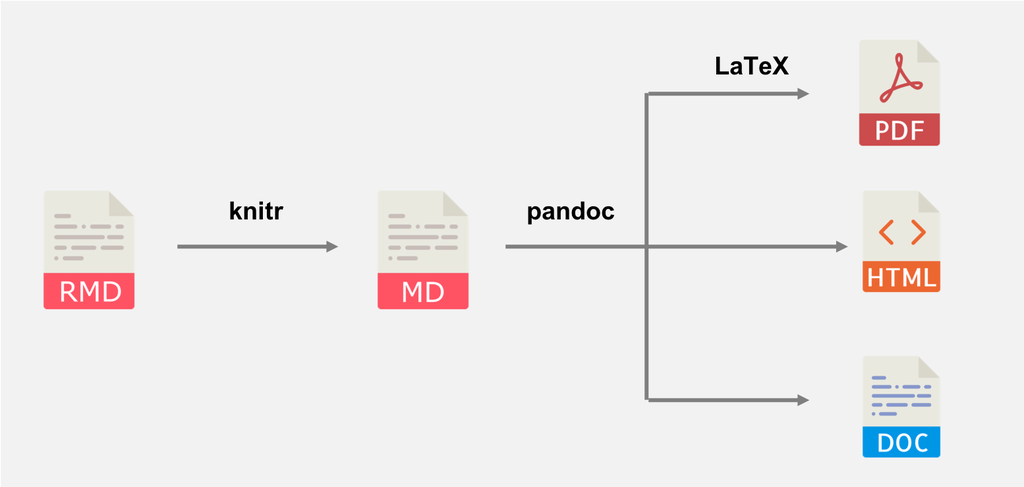

Settings for R Markdown documents are found in the top ribbon. They include those found in R Scripts as well as:

1. Knit—choose which type of document to export to (Knit) and specify if you want to use parameters
2. Gear—change how Knit document is viewed
3. Insert New Code Chunk—can select which programming language to use. You can use R, Python, SQL, and more.
4. Run—run selected lines or run certain code chunks
5. Switch to Visual Markdown Editor—kinda like an email interface instead of just a plain text editor. It does seem to change the `.Rmd` file so I would save before trying this.

An R Markdown document is good because it runs all code chunks sequentially when exporting. This avoids any accidental mistakes that could result from only running certain code chunks in your `.Rmd` file before exporting. For this reason I will likely use R Markdown documents the most. Also good as you can set global options to show or hide code or error messages.

### R Notebook Document

An R Notebook document uses the `.nb.html` extension. This document behaves differently depending on the program that opens it.

1. When the R Notebook document is opened by RStudio, RStudio extracts a `.Rmd` file from the R Notebook document. This `.Rmd` file is identical to the `.Rmd` file used in in R Markdown, except its YAML header specifies “html_notebook” as the output.
2. When the R Notebook document is opened in a web browser, it is similar to the HTML file exported from the R Markdown document. Differences include:
   1. Only code chunks run within the `.Rmd` file at the time of saving display their output
   2. You can toggle code input on or off interactively
   3. You are also able to use the `.nb.html` file to download the source `.Rmd` document if you want the plain text file
   4. You can open the `.nb.html` file in RStudio. RStudio will extract and open the `.Rmd` file

An R Notebook document is good if you want to be able to share your `.nb.html` and `.Rmd` file in one document. It is also good if you want the recipient to be able to control if R code is hidden or displayed.

### Reproducible Research

Both an R Markdown and R Notebook document create reproducible research. **Reproducible research** is a term for an analysis that can easily be replicated. Having statistical methods laid out with explanations allows other researchers to learn from the analysis, assess its validity, and recreate the analysis with the same or new data.

### RStudio Shortcuts

| Shortcut | Use |
| --- | --- |
| `Alt + Shift + K` | Brings up menu of keyboard shortcuts |
| `Ctrl + O` | Open document |
| `Ctrl + S` | Save document |
| `Ctrl + Alt + I` | Insert new code chunk |
| `Ctrl + Shift + Enter` | Run current code chunk |
| `Ctrl + Shift + K` | Knit document |

# R Programming Language

## Introduction

R is a statistical programming language created in 1993. R is based upon S. S is a also a statistical programming language, which was created in 1976. S got its name because it was used for **S**tatistics. R is licensed as a GNU project (open source software). R is written in C, Fortran, and R itself. R is object oriented and interpreted.

## Variables

- **Object**—data, functions, and more that are usually assigned to variable names
- **Variable**—name given to object so that you can easily use that object later on
- Variable names must start with a letter
- Variable names are case sensitive
- Variable names may include letters, numbers, periods, and underscores
- Some recommended that you use *snake_case* to name variables, but *camelCase/CamelCase* is also used
- Reserved words (TRUE, FALSE, NULL, if…etc) can not be used as variable names. These are words that have special meaning in R.
- R allows you to assign the same value to multiple variables in one line of code

## Print

Printing means to display an an object on the screen. In the Console you can just type in the object or variable name of the object and press Enter to display it. Similar when running a script. In this R Markdown document the code input will be displayed in a grey box while the code output will be displayed in a white box and start with the `#>` symbols.

```r
"This text will display on the screen"
```

```
#> [1] "This text will display on the screen"
```

The `print()`function explicitly tells R to display the object. You only need to use this in certain compound statements like in `for` loops.

```r
print("This text will also display on the screen")
```

```
#> [1] "This text will also display on the screen"
```

## Comments

Anything after a pound sign is not executed by R. Used to make comments and “comment out” lines of code when debugging. Comments can come at the beginning of a line or somewhere within it. Unlike Python, there is no syntax for multi-line comments. Instead, `#` is used on each consecutive line.

```r
# This is a comment
"This is not a comment" # This is a comment
```

```
#> [1] "This is not a comment"
```

```r
# This is a comment
# This is a comment
```

## Operators

### Comparison Operators

| Operator | Explanation |
| --- | --- |
| `==` | Equal |
| `!=` | Not equal |
| `<` | Less than |
| `<=` | Less than or equal |
| `>` | Greater than |
| `>=` | Greater than or equal |

### Arithmetic Operators

| Operator | Explanation |
| --- | --- |
| `+` | Addition |
| `-` | Subtraction |
| `*` | Multiplication |
| `/` | Division |
| `^` | Exponent |
| `%%` | Modulus (answer is remainder) |
| `%/%` | Floor Division (answer is rounded down to nearest integer) |

### Logical/Boolean Operators

| Operator | Explanation |
| --- | --- |
| `&` | AND. Returns TRUE if both *elements* TRUE. |
| `&&` | AND. Returns TRUE if both *statements* are TRUE. Special version used with vectors in `if` statements. |
| `\|` | OR. Returns TRUE if either *element* TRUE. |
| `\|\|` | OR. Returns TRUE if either *statement* TRUE. Special version used with vectors in `if` statements. |
| `!` | NOT. Inverts current TRUTH Value. |

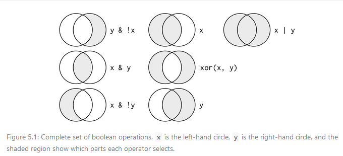

Boolean Operator

### Assignment Operators

| Operator | Use |
| --- | --- |
| `<-` | Assignment operator. Gives an object a variable name. |
| `=` | Same as `<-`, but NOT recommended as in certain circumstances it can cause errors |
| `<<-` | Global assignment operator |
| `->` and `->>` | Assignment operators can be flipped around if desired |

```r
x <- 1 # Assign
x # Print
```

```
#> [1] 1
```

When you assign an object a variable name, R normally does not print the object also. To both assign and print at the same time, surround the entire statement in `()`.

```r
(x <- 1) # Assign and print
```

```
#> [1] 1
```

### Miscellaneous Operators

| Operator | Explanation |
| --- | --- |
| `:` | Creates a series of numbers in a sequence |
| `%in%` | Find out if an element is in an object. Used to shorten other conditional expressions that are repetitive. |
| `%*%` | Matrix Multiplication |

The following two code chunks do the same thing. The latter uses `:` and `%in%` in order to shorten the code input.

```r
(1 == 1) | (1 == 2) | (1 == 3) | (1 == 4) | (1 == 5)
```

```
#> [1] TRUE
```

```r
1 %in% c(1:5)
```

```
#> [1] TRUE
```

## Style Guidelines

See the link to style guidelines in the *Resources* section of this document. Important takeaways are:

- Use snake_case for most variable names
- Use double quotes instead of single most of the time
- Use `<-` and not `=`
- Use `TRUE` and `FALSE` over `T` and `F`
- Put spaces around operators. A a few exceptions include: `n:n`, `n^n`, `df$column_name`.
- Try to limit line length to about 80 characters
- When indenting in compound statements (if, while, for, etc.) use two spaces
- In compound statements the curly braces should usually look like:

E.g.

```
while (condition) {
  statement
  if (condition) {
    statement
  }
}
```

## Data Types

- The data “type” is similar to how MS Excel has different cell types like numbers, dates, text, money, etc. In general, data types describe how the data is stored in the computer and how it can be used by functions.
- In R, the main data types are seen within a very flexible and fundamental object called a **vector**. It is like a list that can have 0 items, 1 item, or >1 item. The number of items in the object is called the **length**. According to the *R Language Definition*:

> Single numbers, such as 4.2, and strings, such as “four point two” are still vectors, of length 1; there are no more basic types. Vectors with length zero are possible (and useful).
- As stated a vector can store real numbers and string data. They can also store integers, logical values, complex numbers, and raw data. Complex numbers and raw data are rarely used by the average person. Vector data types are seen in the following table:

| Vector Data Type | Explanation | Example | Python Equivalent |
| --- | --- | --- | --- |
| character | String of characters. | “Hello world” | String |
| double | Real numbers. Double floating point. | -1.1, 1, 1.1 | Float |
| integer | Integers. Declared using `L` | -1L, 0L, 1L | Integer |
| complex | Real and imaginary numbers together | 4 + 2i | Complex |
| logical | Truth values | TRUE, FALSE | Boolean |
| raw | Doesn’t matter | Doesn’t matter | No idea |
| NA | Absence of data within vector | NA | None |

- Vectors themselves are broken up into two categories:
  1. **Atomic vectors**—must contain only one data type within the atomic vector. This is what most people are referring to when they say the word “vector”.
  2. **Lists**—may contain multiple data types within the same list. They may also contain multiple data structures within the same list.

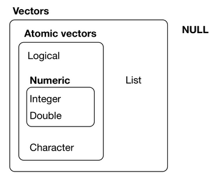

- Vectors are used to create all the other **data structures** in R. These other data structures are sometimes called **augmented vectors**. These data structures vary on the dimensions (single row of data, table of data, or cube of data) and whether they are homogeneous or not (if they can contain only one data type or multiple data types). We’ll go over each data structure in more detail in its own section.

**Comparison of Data Structures**

| Dimensions | Homogenous | Heterogenous |
| --- | --- | --- |
| 1D | Vector, Factor | List |
| 2D | Matrix | Data Frame |
| nD | Array |  |

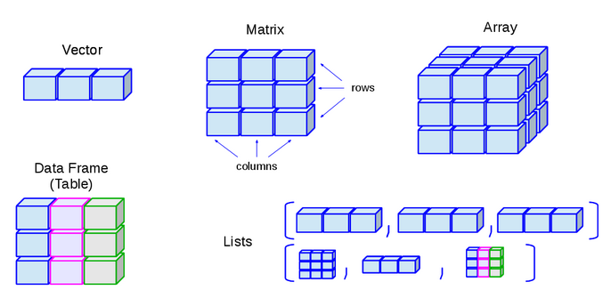

- Lastly, in R there are a few related terms to describe the “type” of data. There is “type”, “class”, and “mode”. Only advanced R users need to understand the differences. Suffice it to say that class is a higher level category and type is more fundamental. We’ll just use the term type.

[output not shown]

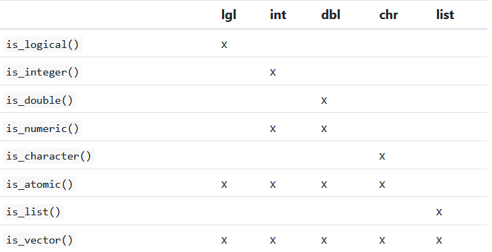

## NA and NULL

**NULL**—an object that represents the absence of a vector. NULL typically behaves like a vector of length 0.

**NA**—within a vector, NA represents the absence of a value. If NA is used in calculations it usually creates more NA values. NA is “contagious”. Though NA is used the vast majority of times, it is possible that you will see more specific NAs for each data type.

| Missing Value | Data Type |
| --- | --- |
| NA | Logical |
| NA_integer_ | Integer |
| NA_real_ | Double |
| NA_character_ | Character |

There are also some less used special values that can come from double type numbers

| Missing Value | Why? |
| --- | --- |
| Inf | Special value that results when a positive double type number is divided by 0 |
| -Inf | Special value that results when a negative double type number is divided by 0 |
| NaN | Special value that results when a 0 double type number is divided by 0 |

[output not shown]

**is.na()**

```r
a <- NA
b <- 5
a == b
```

```
#> [1] NA
```

```r
is.na(a)
```

```
#> [1] TRUE
```

```r
is.na(b)
```

```
#> [1] FALSE
```

## Atomic Vector

- An atomic vector is a “list” of elements/items of the same data type. “List” is in quotes as list is itself the name of another data structure.
- They are usually referred to simply as ” vectors”
- A single numerical value, string, or logical value is technically a vector of length one. A vector of length one is called a **scalar**. When the length of the vector is 1 it does not require any special syntax. E.g.
  - `1.23`
  - `1L`
  - `"Hello world"`
  - `TRUE`
- A vector with more than one item requires you to separate items with commas and place the “list” within the `c()` function. E.g.
  - `c("a", "b", "c")`
- **Index position**—the position of elements within the vector. In R, the index position starts at 1. In the above example “a” is at index position one, while “b” is at index position 2, and “c” is at index position 3.
- **Attributes**—while most vectors are just a list of values, vectors can have additional character data attached to each value. The “attribute” is the portion before the `=`. The value is the portion after the `=`. Attributes are rarely used in atomic vectors, but are important for making more complex data structures like data frames.
- **Coercion**—vectors can only contain one data type. Changing data types can happen explicitly or implicitly:
  - **Explicitly**—convert between data types using `as.logical()`, `as.integer()`, `as.double()`, or `as.character()`.
  - **Implicitly**—when multiple data types are accidentally used together R automatically converts all values into the most “flexible” type. Types from least to most flexible are logical, integer, double, and character.
    - E.g. if you mix logical and character then the logical will be converted into a character (add quotes).
- **Recycling**—when two vectors are used in a function or operation, sometimes those vectors are required to be the same length. If one vector is shorter R implicitly reuses elements of the shorter vector. When the shorter vector is of length one it essentially does a for loop through the longer variable.

[output not shown]

**Create Vector with c()**

```r
my_vec <- c("a", "b", "c")
```

**Combine Vectors with c()**

```r
my_vec1 <- c("a", "b", "c")
my_vec2 <- c("d","e")
my_vec3 <- c(my_vec1, my_vec2)
my_vec3
```

```
#> [1] "a" "b" "c" "d" "e"
```

**Create Vector with :**

```r
my_vec <- 1:10
my_vec
```

```
#>  [1]  1  2  3  4  5  6  7  8  9 10
```

**seq()**

```r
my_vec <- seq(1,10,2)
my_vec
```

```
#> [1] 1 3 5 7 9
```

**length()**

```r
length(1:10)
```

```
#> [1] 10
```

**vector()**

```r
vector(mode = "character", length = 3)
```

```
#> [1] "" "" ""
```

**%in%**

```r
my_vec <- c("a", "b", "c")
"a" %in% my_vec
```

```
#> [1] TRUE
```

**Indexing**

```r
my_vec <- c("a", "b", "c")
my_vec[1]
```

```
#> [1] "a"
```

```r
my_vec[1:2]
```

```
#> [1] "a" "b"
```

```r
my_vec[c(1,3)]
```

```
#> [1] "a" "c"
```

**Negative Indexing**

```r
my_vec <- c("a", "b", "c")
my_vec[(-1)]
```

```
#> [1] "b" "c"
```

**“Delete” with Negative Indexing**

```r
my_vec <- c("a", "b", "c")
new_vec <- my_vec[-1]
new_vec
```

```
#> [1] "b" "c"
```

**Replace Element**

```r
my_vec <- c("a", "b", "c")
my_vec[2] <- "d"
my_vec
```

```
#> [1] "a" "d" "c"
```

**append()**

```r
my_vec <- c("a", "b", "c")
new_vec <- append(my_vec, c("d", "e"))
new_vec
```

```
#> [1] "a" "b" "c" "d" "e"
```

**Attributes**

```r
my_vec <- c(x = "a", y = "b", z = "c")
my_vec["y"]
```

```
#>   y
#> "b"
```

**Coercion Explicit Example 1**

You can go from less flexible to more flexible

```r
my_vec <- c(TRUE, FALSE)
as.integer(my_vec)
```

```
#> [1] 1 0
```

```r
as.double(my_vec)
```

```
#> [1] 1 0
```

```r
as.character(my_vec)
```

```
#> [1] "TRUE"  "FALSE"
```

**Coercion Explicit Example 2**

You can’t go from more flexible to less flexible

```r
my_vec <- c("a", "b", "c")
as.logical(my_vec)
```

```
#> [1] NA NA NA
```

**Coercion Implicit**

```r
typeof(TRUE)
```

```
#> [1] "logical"
```

```r
typeof(c(TRUE, 3L))
```

```
#> [1] "integer"
```

```r
typeof(c(TRUE, 3L, 3))
```

```
#> [1] "double"
```

```r
typeof(c(TRUE, 3L, 3, "Dog"))
```

```
#> [1] "character"
```

**Recycling Example with Vector Length 1**

A vector of length one loops through the longer vector like it was in a for loop

```r
10 + c(1,2,3,4,5)
```

```
#> [1] 11 12 13 14 15
```

**Recycling Example with Vector Length > 1**

If the shorter vector is not length one R automatically does weird loopy things (alternates matching values from both vectors)

```r
c(10, 11) + c(1,2,3,4,5)
```

```
#> [1] 11 13 13 15 15
```

## Numeric Data

- Vectors may contain integer, double, and complex number data types
- Vectors of length 1 may have a single number and requires no additional syntax besides the number itself. E.g.
  - `1L`
  - `1.1`
- Vectors can also list multiple numbers separated by commas within the `c()` function. E.g.
  - `c(1L,2L,3L)`
  - `c(1.1, 2.2, 3.3)`
- If you want to specify an integer you need to write an `L` after the number. E.g.
  - `3L`
- By default R uses the double type for numbers
- The double type is an approximation of a real number
  - Because it takes computer memory to store information only so many digits are saved. Thus, numbers with many decimals are rounded.
  - Furthermore, decimal numbers are stored as base 2 numbers (0s and 1s) in a computer. Some fractions easily expressed in base 10, require many digits in base 2 and must be rounded. For both these reasons, doubles are approximations.
  - See `near()` below
- R includes arithmetic and comparative operators to do basic math
- R has some basic math functions built-in. We’ll cover more advanced statistical functions in another R Markdown document.

[output not shown]

**pi**

```r
pi
```

```
#> [1] 3.141593
```

**log10()**

```r
log10(100)
```

```
#> [1] 2
```

**near()**

```r
2/3 == 0.66666666666666
```

```
#> [1] FALSE
```

```r
near((2/3), 0.66666666666666)
```

```
#> [1] TRUE
```

## Character Data

- Vectors may contain character data
- A sequence of characters surrounded by quotes is called a string
- Single or double quotes can be used to indicate a string. Though they are equivalent, it is recommended to use double quotes.
- Vectors of length 1 may have a single string and require no additional syntax besides the string itself. E.g.
  - “Hello world”
- Vectors can also list multiple strings separated by commas within the `c()` function. E.g.
  - `c("a", "b", "c")`
- If you are using the Console and forget to put a quote at the end of the string R will prompt you with a `+` sign to input more info. You can always click the Escape key to stop inputting.
- String characters are not indexed like a string in Python
- Supposedly built-in functions that work with string data can be inconsistent, so it is recommended to use functions in the stringr package.
- See the stringr package under *Tidy + Transform = Wrangle*

| Function | Use |
| --- | --- |
| `LETTERS` | Built-in constant that is a vector of upper case letters |
| `letters` | Built-in constant that is a vector of lower case letters |
| `month.abb` | Built-in constant that is a vector of shortened month names |
| `month.name` | Built-in constant that is a vector of month names |
| `cat()` | Prints, displaying new line white space. The `\n` indicates where a new line is. The normal `print()` function does not automatically use the `\n` to display new line white space. |

**LETTERS**

```r
LETTERS
```

```
#>  [1] "A" "B" "C" "D" "E" "F" "G" "H" "I" "J" "K" "L" "M" "N" "O" "P" "Q" "R" "S"
#> [20] "T" "U" "V" "W" "X" "Y" "Z"
```

**cat()**

```r
print("Hello \n world")
```

```
#> [1] "Hello \n world"
```

```r
cat("Hello \n world")
```

```
#> Hello
#>  world
```

**Characters are Not Indexed**

```r
my_string <- "Hello world"
print(my_string[2]) # Does NOT return e
```

```
#> [1] NA
```

### Escape Characters

Escape characters are characters preceded by `\` that have special meaning. R treats them as a single character

| Code | Name | Use |
| --- | --- | --- |
| `\"` | Double Quotes | Able to put quotes where they would ordinarily cause an error |
| `\'` | Single Quote | Able to put quotes where they would ordinarily cause an error |
| `\\` | Backslash | Inserts one backslash and cancels out any escape function the single backslash was doing |
| `\n` | New line, NL | Inserts line of white space. |
| `\t` | Tab | Inserts a tab of white space |
| `\unicode` | Unicode | Inserts a non-English character that works on all platforms. The portion after the backslash is the desired Unicode code point. |

**`\n`**

```r
cat("Hello \n world")
```

```
#> Hello
#>  world
```

**`\t`**

```r
cat("sh\t!")
```

```
#> sh   !
```

**`\'`**

```r
cat('Frickin\' laser beam')
```

```
#> Frickin' laser beam
```

**`\"`**

```r
cat("Frickin \"laser\" beam")
```

```
#> Frickin "laser" beam
```

**`\"`**

```r
cat("If you want to indclude a \\ in a string, you must write two of them next to each other.")
```

```
#> If you want to indclude a \ in a string, you must write two of them next to each other.
```

***

```r
cat("\U00F1")
```

```
#> ñ
```

## Date and Time Data

- Date and time data does not get its own type of vector. Instead, it is built on top of numeric vectors
- Because R does not have great way of working with times built-in, the **hms** package is often used when you are working with time data
- The lubridate package is used for date and date-time data. See *Tidy + Transform = Wrangle*.

Dates and times are seemingly simple, yet apparently, frustratingly complex. See this video about [time zones](https://www.youtube.com/watch?v=-5wpm-gesOY&t=612s). Along with time zones, there are three simple questions that embody this:

1. How many days in a year? 365!…unless it is a leap year. Leap years happen every 4 years!…unless the year can be evenly divided by 100, then it’s not!…unless it is also divisible by 400, then it is!
2. How many hours in a day? 24!…unless a given location celebrates daylight saving time. Then it’s 23 and 25 once a year!
3. How many seconds in a minute? 60!…unless there is leap second, then it’s 61!

There are three options for working with dates and time:

1. date. Tibbles print this as `<date>`
2. time. Tibbles print this as `<time>`
3. date-time. Tibbles print this as `<dttm>`. Internally R uses the term `<S3: POSIXct>` which stands for “Portable Operating System Interface calendar time”.
- You should use the simplest data that works with your needs. Because time zones are so complicated, it is recommended to work solely with `<date>` data when possible.

## List

- A list is similar to an atomic vector, but it can hold one or more data types
- A list can have character, numeric, integer, complex, and logical data types all together
- A list can also contain other data structures. This means that a single list could have a character atomic vector, a double atomic vector, a data frame, and another list all together!
- Because lists can contain lists, they are sometimes called recursive vectors

| Function | Use |
| --- | --- |
| `list()` | Returns list |

**list() Simple Example**

```r
str(list(1,2))
```

```
#> List of 2
#>  $ : num 1
#>  $ : num 2
```

**list() Complex Example**

```r
my_list <- list(1,"a", 2L, c(3, "b"), list(4, "c"))
str(my_list)
```

```
#> List of 5
#>  $ : num 1
#>  $ : chr "a"
#>  $ : int 2
#>  $ : chr [1:2] "3" "b"
#>  $ :List of 2
#>   ..$ : num 4
#>   ..$ : chr "c"
```

**list() with Attribute Value Pairs**

```r
my_list <- list(
             name = "John Doe",
             student_id = 1234,
             grades = c(95, 82, 91, 97, 93),
             final_grade = "A",
            random_list = list(c(1, "a", 3))

           )

my_list
```

```
#> $name
#> [1] "John Doe"
#>
#> $student_id
#> [1] 1234
#>
#> $grades
#> [1] 95 82 91 97 93
#>
#> $final_grade
#> [1] "A"
#>
#> $random_list
#> $random_list[[1]]
#> [1] "1" "a" "3"
```

## Factor

- A factor is a “list” of categories. “List” is in quotes as list is itself the name of another data structure.
- **Level**—each unique category name
  - E.g. the following factor, `Jazz, Classical, Rock, Rock`, has 4 elements/items in the factor. It has 3 levels, `Jazz`, `Classical` and `Rock`.
- You can only add elements to the factor, if that element is already a level
  - E.g. I could NOT add a “Pop” element to the factor above, but I could add another “Jazz” element
- If you use the `typeof()` function on a factor it will return “integer”. This is because factors are built on top of integer vectors that have attributes. You can start to see how integers are mapped to factor items and levels if you use `str()`.
- See the forcats package under *Tidy + Transform = Wrangle* for more information on working with factors. Forcats is especially useful for managing levels.

[output not shown]

**factor()**

This sets levels automatically

```r
my_fact <- factor(c("Jazz", "Classical", "Rock", "Rock"))
my_fact
```

```
#> [1] Jazz      Classical Rock      Rock
#> Levels: Classical Jazz Rock
```

```r
typeof(my_fact)
```

```
#> [1] "integer"
```

```r
str(my_fact)
```

```
#>  Factor w/ 3 levels "Classical","Jazz",..: 2 1 3 3
```

**levels()**

```r
my_fact <- factor(c("Jazz", "Classical", "Rock", "Rock"))
levels(my_fact)
```

```
#> [1] "Classical" "Jazz"      "Rock"
```

**Define Levels**

This manually defines levels, allowing us to define the level “Pop”.

```r
my_fact <- factor(
  c("Jazz", "Classical", "Rock", "Rock"),
  levels = c("Pop", "Classical", "Jazz", "Rock")
)
my_fact
```

```
#> [1] Jazz      Classical Rock      Rock
#> Levels: Pop Classical Jazz Rock
```

## Matrix

- A matrix is a two dimensional data set with columns and rows
- Essentially a 2D vector
- Matrices can only have one data type
- When creating matrices, you must have the correct number of items/values to fill the table or you will receive an error message
  - E.g. A table with 3 rows and 3 columns needs to have 9 items/values entered into it
- Matrix elements/items/values can be accessed using indexing
- Matrices are more used behind the scenes by R. Not often used in data analysis.

| Function | Use |
| --- | --- |
| `matrix()` | Returns new matrix. Arguments are a vector of data, nrow, and ncol. |

**Create Matrix**

```r
my_matrix <- matrix(c('a', 'b', 'c', 'd'), nrow = 2, ncol = 2)
my_matrix
```

```
#>      [,1] [,2]
#> [1,] "a"  "c"
#> [2,] "b"  "d"
```

## Array

- An array is a matrix that can have more than two dimensions
  - I.e. a multidimensional vector (sounds pretty cool to say)
  - A Rubik’s Cube of data.
- Can only have one data type
- Will likely never use this data structure

| Function | Use |
| --- | --- |
| `array()` | Returns array. Arguments are vector of values, and `dim = c(# rows, # col, # D)` |

```r
my_vec <- 1:8
my_array <- array(my_vec, dim = c(2, 2, 3))
my_array
```

```
#> , , 1
#>
#>      [,1] [,2]
#> [1,]    1    3
#> [2,]    2    4
#>
#> , , 2
#>
#>      [,1] [,2]
#> [1,]    5    7
#> [2,]    6    8
#>
#> , , 3
#>
#>      [,1] [,2]
#> [1,]    1    3
#> [2,]    2    4
```

## Data Frame

- A data frame (DF) is a table
- Rows are called observations (or records). Rows usually represent nouns.
- Columns are called variables (or attribute fields). Columns usually represent attributes of the nouns.
- Different columns can have different data types
- Within the same column the data type must stay the same
- Data frames are built on top of lists
- Most used data structure in R when doing data analysis

| Function | Use |
| --- | --- |
| `data.frame()` | Create a new DF made from scratch. For each column in the DF you specify the column name and then provide a vector with column values. |
| `as.data.frame()` | Return a new DF. Argument is existing matrix or tibble. |
| `dim()` | Returns the number of rows and the number of columns |
| `nrow()` | Return the number of rows |
| `ncol()` | Return the number of columns |
| `length()` | Same as `ncol()` |
| `names()` | Returns the names of the columns |
| `[#:#, #:#]` | Return a new DF with specified rows and columns in it. Like matrix, you list rows first and columns second. Can specify a single column with a name or with a number. |
| `$` | Return one column’s worth of values as a vector. This is important because some functions require a vector input and not a DF input. |
| `rbind()` | Return new DF with new row added. Arguments are old DF name and new row values. Can also add a new DF vertically. |
| `cbind()` | Return new DF with new column added. Arguments are old DF name, new column name, and new column values. Can also add a new DF horizontally. |
| `[-c(#), -c(#)]` | Return new DF with all rows or columns **except** the ones specified |

**data.frame()**

```r
my_data_frame <- data.frame(
  snipe_bird_name = c('Bob', 'Frank', 'Jill', 'Pauline', 'Roger'),
  height = c(10, 15, 20, 25, 30),
  weight = c(100, 125, 150, 175, 200)
)
my_data_frame
```

```
#>   snipe_bird_name height weight
#> 1             Bob     10    100
#> 2           Frank     15    125
#> 3            Jill     20    150
#> 4         Pauline     25    175
#> 5           Roger     30    200
```

**Size of DF**

```r
my_data_frame <- data.frame(
  snipe_bird_name = c('Bob', 'Frank', 'Jill', 'Pauline', 'Roger'),
  height = c(10, 15, 20, 25, 30),
  weight = c(100, 125, 150, 175, 200)
)
dim(my_data_frame)
```

```
#> [1] 5 3
```

```r
nrow(my_data_frame)
```

```
#> [1] 5
```

```r
ncol(my_data_frame)
```

```
#> [1] 3
```

```r
length(my_data_frame)
```

```
#> [1] 3
```

**names()**

```r
my_data_frame <- data.frame(
  snipe_bird_name = c('Bob', 'Frank', 'Jill', 'Pauline', 'Roger'),
  height = c(10, 15, 20, 25, 30),
  weight = c(100, 125, 150, 175, 200)
)

names(my_data_frame)
```

```
#> [1] "snipe_bird_name" "height"          "weight"
```

**Access Items with []**

```r
my_data_frame <- data.frame(
  snipe_bird_name = c('Bob', 'Frank', 'Jill', 'Pauline', 'Roger'),
  height = c(10, 15, 20, 25, 30),
  weight = c(100, 125, 150, 175, 200)
)
my_data_frame # Return entire DF
```

```
#>   snipe_bird_name height weight
#> 1             Bob     10    100
#> 2           Frank     15    125
#> 3            Jill     20    150
#> 4         Pauline     25    175
#> 5           Roger     30    200
```

```r
my_data_frame[1,] # Return DF with 1st row
```

```
#>   snipe_bird_name height weight
#> 1             Bob     10    100
```

```r
my_data_frame[,1] # Return vector with 1st column (could also use column name here in quotes)
```

```
#> [1] "Bob"     "Frank"   "Jill"    "Pauline" "Roger"
```

```r
my_data_frame[1] # Return DF with 1st column (could also use column name here in quotes)
```

```
#>   snipe_bird_name
#> 1             Bob
#> 2           Frank
#> 3            Jill
#> 4         Pauline
#> 5           Roger
```

```r
my_data_frame[2,3] # Return a single item from 2nd row, from 3rd column
```

```
#> [1] 125
```

```r
my_data_frame[2:3] # Return DF with columns 2 through 3
```

```
#>   height weight
#> 1     10    100
#> 2     15    125
#> 3     20    150
#> 4     25    175
#> 5     30    200
```

```r
my_data_frame[1:2,2:3] # Return DF with rows 1-2, with columns 2-3
```

```
#>   height weight
#> 1     10    100
#> 2     15    125
```

**Access Items in a Column with $**

```r
my_data_frame <- data.frame(
  snipe_bird_name = c('Bob', 'Frank', 'Jill', 'Pauline', 'Roger'),
  height = c(10, 15, 20, 25, 30),
  weight = c(100, 125, 150, 175, 200)
)
my_data_frame$snipe_bird_name
```

```
#> [1] "Bob"     "Frank"   "Jill"    "Pauline" "Roger"
```

**Add Row**

```r
my_data_frame <- data.frame(
  snipe_bird_name = c('Bob', 'Frank', 'Jill', 'Pauline', 'Roger'),
  height = c(10, 15, 20, 25, 30),
  weight = c(100, 125, 150, 175, 200)
)
new_data_frame <- rbind(my_data_frame, c('Selma', 35, 225))
new_data_frame
```

```
#>   snipe_bird_name height weight
#> 1             Bob     10    100
#> 2           Frank     15    125
#> 3            Jill     20    150
#> 4         Pauline     25    175
#> 5           Roger     30    200
#> 6           Selma     35    225
```

**Add DF Vertically**

```r
my_data_frame <- data.frame(
  snipe_bird_name = c('Bob', 'Frank', 'Jill', 'Pauline', 'Roger'),
  height = c(10, 15, 20, 25, 30),
  weight = c(100, 125, 150, 175, 200)
)
new_data_frame <- rbind(my_data_frame, my_data_frame) # We could add a different table if we wanted
new_data_frame
```

```
#>    snipe_bird_name height weight
#> 1              Bob     10    100
#> 2            Frank     15    125
#> 3             Jill     20    150
#> 4          Pauline     25    175
#> 5            Roger     30    200
#> 6              Bob     10    100
#> 7            Frank     15    125
#> 8             Jill     20    150
#> 9          Pauline     25    175
#> 10           Roger     30    200
```

**Add Column**

```r
my_data_frame <- data.frame(
  snipe_bird_name = c('Bob', 'Frank', 'Jill', 'Pauline', 'Roger'),
  height = c(10, 15, 20, 25, 30),
  weight = c(100, 125, 150, 175, 200)
)
new_data_frame <- cbind(my_data_frame, snipe_age = c(1000, 1100, 1200, 1300, 1400))
new_data_frame
```

```
#>   snipe_bird_name height weight snipe_age
#> 1             Bob     10    100      1000
#> 2           Frank     15    125      1100
#> 3            Jill     20    150      1200
#> 4         Pauline     25    175      1300
#> 5           Roger     30    200      1400
```

**Add DF Horizontally**

```r
my_data_frame <- data.frame(
  snipe_bird_name = c('Bob', 'Frank', 'Jill', 'Pauline', 'Roger'),
  height = c(10, 15, 20, 25, 30),
  weight = c(100, 125, 150, 175, 200)
)
new_data_frame <- cbind(my_data_frame, my_data_frame) # We could add a different table if we wanted
new_data_frame
```

```
#>   snipe_bird_name height weight snipe_bird_name height weight
#> 1             Bob     10    100             Bob     10    100
#> 2           Frank     15    125           Frank     15    125
#> 3            Jill     20    150            Jill     20    150
#> 4         Pauline     25    175         Pauline     25    175
#> 5           Roger     30    200           Roger     30    200
```

**Remove Row and Column**

```r
my_data_frame <- data.frame(
  snipe_bird_name = c('Bob', 'Frank', 'Jill', 'Pauline', 'Roger'),
  height = c(10, 15, 20, 25, 30),
  weight = c(100, 125, 150, 175, 200)
)
new_data_frame <- my_data_frame[-c(1,2,3), -c(3)] # Remove rows 1,2,3 and 3rd column
new_data_frame
```

```
#>   snipe_bird_name height
#> 4         Pauline     25
#> 5           Roger     30
```

## Tibble

The name “tibble” comes from `tbl_df`, which is the name of this data structure inside of R. It was easier to read this as “tibble diff” than “table data frame”. It was then shortened to “tibble”.

Tibbles are found in the tibble package, which is imported when the tidyverse package is imported

Tibbles *are* data frames. They just implement a few changes intended to make data more “tidy”. See tibble vignette for more detail on this. As far I know every function that works with a traditional DF also works with a tibble. Throughout this text when we talk about function inputs and outputs we will usually use the term data frame (or more likely DF), but know that you could also use a tibble in these locations. There a handful of differences between data frames and tibbles:

- Tibbles never changes the data type. A DF may automatically coerce data without the user realizing. A common problem (apparently) is data being changed from a string to a factor.
- A tibble can have columns with lists as the data type
- A tibble can have non-standard variable names. Tibble names can start with a number and contain spaces. To use these non-standard names you must flank the names in backticks when referring to them. DFs can automatically change your variable name (like replacing a space with a period) without the user realizing it.
- Tibbles only recycle vectors of length 1
- Tibbles never create row names. Not sure what this means.
- Tibbles only print the first 10 rows and all columns that fit on the screen. DFs print more rows and all the columns. This way you do not accidentally print too much and make it hard to read your output.
- When you access/subset your data using `[]` a tibble always returns another tibble. DFs sometimes return a DF and sometimes return a vector.
- When you access your data with a `$` a tibble requires a 100% match between the text you type and the actual column name. A DF allows a partial match.
- Tibbles do not support arithmetic operations on all columns, while DFs do. If you try to do operations on all columns the tibble is silently coerced to a data frame. Do not rely on this behavior. Not sure what this means.

| Function | Use |
| --- | --- |
| `tibble()` | Returns new tibble. Arguments are vectors that will act as columns. |
| `as_tibble()` | Returns new tibble. Argument is an existing DF or matrix. |

**tibble() Simple**

```r
tibble(
  snipe_bird_name = c('Bob', 'Frank', 'Jill', 'Pauline', 'Roger'),
  height = c(10, 15, 20, 25, 30),
  weight = c(100, 125, 150, 175, 200)
)
```

```
#> # A tibble: 5 x 3
#>   snipe_bird_name height weight
#>   <chr>            <dbl>  <dbl>
#> 1 Bob                 10    100
#> 2 Frank               15    125
#> 3 Jill                20    150
#> 4 Pauline             25    175
#> 5 Roger               30    200
```

**tibble() Complex**

```r
tibble(
  `: )` = c('Bob', 'Frank'), # Backticks
  locations = c(list(c(1,2,3)), list(c(4,5,6))), # Lists
  height = 500, # Recycling one item
  weight = c(10,20),
  `h x w` = height*weight # Not tibble specific, but interesting that this works
)
```

```
#> # A tibble: 2 x 5
#>   `: )` locations height weight `h x w`
#>   <chr> <list>     <dbl>  <dbl>   <dbl>
#> 1 Bob   <dbl [3]>    500     10    5000
#> 2 Frank <dbl [3]>    500     20   10000
```

**as.tibble()**

```r
as_tibble(iris)
```

```
#> # A tibble: 150 x 5
#>    Sepal.Length Sepal.Width Petal.Length Petal.Width Species
#>           <dbl>       <dbl>        <dbl>       <dbl> <fct>
#>  1          5.1         3.5          1.4         0.2 setosa
#>  2          4.9         3            1.4         0.2 setosa
#>  3          4.7         3.2          1.3         0.2 setosa
#>  4          4.6         3.1          1.5         0.2 setosa
#>  5          5           3.6          1.4         0.2 setosa
#>  6          5.4         3.9          1.7         0.4 setosa
#>  7          4.6         3.4          1.4         0.3 setosa
#>  8          5           3.4          1.5         0.2 setosa
#>  9          4.4         2.9          1.4         0.2 setosa
#> 10          4.9         3.1          1.5         0.1 setosa
#> # ... with 140 more rows
```

### Tribble

- The name `tribble()` comes from **tr**ansposed tibble.
- `tribble()` is not a table, unlike tibble and data frame. `tribble()` is simply a function that creates a tibble that differs in format from the `tibble()` function.
- `tibble()` accepts data one column at a time
- `tribble()` accepts data one **r**ow at a time. This allows you to create a visual of a small table as you input it.
- Uses `~` for column names
- Can even use `#---|---` to imitate table structure.

```r
tribble(
  ~snipe_bird, ~height, ~weight,
  #---------- | ------ | ------- Obviously optional
  "Bob",         10,      100, # Could even align values in columns with spaces
  "Frank", 15, 125,
  "Jill", 20, 150,
  "Pauline", 25, 175,
  "Roger", 30, 200
)
```

```
#> # A tibble: 5 x 3
#>   snipe_bird height weight
#>   <chr>       <dbl>  <dbl>
#> 1 Bob            10    100
#> 2 Frank          15    125
#> 3 Jill           20    150
#> 4 Pauline        25    175
#> 5 Roger          30    200
```

## Accessor Comparison

**Accessors** are symbols that allow you to subset your data and extract specific values based on their position in a data structure. There are three ways to access values int R. `[]`, `[[]]`, and `$`. Python only has single brackets.

**`[]` Single Brackets**

- Used for subsetting. Can return **multiple** items.
- Returns the **same data type** as the original object. The exception is that sometimes in a DF when you extract a column it will be converted into a vector. Tibbles always return the same data type.
  - E.g. returns a DF column as a single column in a DF
- Both index positions and names can be used
- You can use negative numbers to indicate exclusion

**`[[]]` Double Brackets**

- Used for extracting **one** item by name or index position
- May NOT return the same data type as the original object as it drills down one layer
  - E.g. returns a DF column as a vector of values
- Both index positions and names can be used
- Most used with lists and DFs

**`$` Dollar Sign**

- Same as double brackets except:
  - Does NOT allow use of index position
  - Do not have to put object name in quotes

## Pipes

- `%>%` is called a pipe. The pipe operator allows output from one function to be the input for the next function. The piped in data is used as the first argument in the next function.
- Pipes are found in the magrittr package, which is imported when the tidyverse package is imported. The magrittr author wrote a sweet vignette:

> The magrittr (to be pronounced with a sophisticated french accent) package has two aims: decrease development time and improve readability and maintainability of code. Or even shortr: make your code smokin’ (puff puff)! To achieve its humble aims, magrittr (remember the accent) provides a new “pipe”-like operator, %>%, with which you may pipe a value forward into an expression or function call; something along the lines of x %>% f, rather than f(x). This is not an unknown feature elsewhere; a prime example is the |> operator used extensively in F# (to say the least) and indeed this – along with Unix pipes – served as a motivation for developing the magrittr package. This vignette describes the main features of magrittr and demonstrates some features which have been added since the initial release.

When you want to use output as input there are multiple options. They have pros and cons:

1. **Save new objects**—save each intermediate step as a new object with an assignment statement. This is a great option if you want to use these intermediate objects later. If you don’t it can be bad as writing out lots of variables names is more likely to lead to human errors.
2. **Overwrite**—save each intermediate step, re-using the same name. This is a good option as it decreases the chance of errors. However, it requires unnecessary typing and can distract the user from the purpose of the workflow.
3. **Function composition**—nested functions. Super confusing to read as you read from the “inside-out”.
4. **Pipes**—great most of the time. Becomes confusing to debug if used in a sequence approaching 10 lines long. Does not work with a handful of functions, but normal R users don’t need to worry about this. Ends if function has no output. This last problem can solved with the tee pipe (`%T>%`).

**New Objects**

```r
my_str_1 <- "   Hello   world!   "
my_str_2 <- str_trim(my_str_1)
my_str_3 <- str_squish(my_str_2)
my_str_4 <- str_to_upper(my_str_3)

my_str_1
```

```
#> [1] "   Hello   world!   "
```

```r
my_str_2
```

```
#> [1] "Hello   world!"
```

```r
my_str_3
```

```
#> [1] "Hello world!"
```

```r
my_str_4
```

```
#> [1] "HELLO WORLD!"
```

**Overwrite**

```r
my_str <- "   Hello   world!   "
my_str <- str_trim(my_str)
my_str <- str_squish(my_str)
my_str <- str_to_upper(my_str)

my_str
```

```
#> [1] "HELLO WORLD!"
```

**Function Composition Example 1**

```r
my_str <- "   Hello   world!   "
my_str <- str_to_upper(str_squish(str_trim(my_str)))

my_str
```

```
#> [1] "HELLO WORLD!"
```

**Function Composition Example 2**

```r
my_str <- "   Hello   world!   "
my_str <- str_to_upper(
  str_squish(
    str_trim(
      my_str
      )
    )
  )

my_str
```

```
#> [1] "HELLO WORLD!"
```

**Pipes**

```r
my_str <- "   Hello   world!   " %>%
  str_trim() %>%
  str_squish() %>%
  str_to_upper()

my_str
```

```
#> [1] "HELLO WORLD!"
```

## Conditional Statements

- Conditional statements are “If-Then” statements. **If** a condition is met (TRUE) **then** run code.
- The condition is surrounded by parenthesis. The opening curly brackets can be read as “then”.

Conditional statements have the following syntax:

```r
if (condition) {
  run this code
}
```

Conditional statements can be more complicated as well

```r
if (condition) {
  run this code
} else if (condition) {
  run this code
} else if (condition) {
  run this code
} else {
  run this code
}
```

[output not shown]

**if**

```r
if (1 < 2) {
  print('First condition is TRUE')
}
```

```
#> [1] "First condition is TRUE"
```

**if + else**

```r
if (1 == 2){
  print('First condition is TRUE')
} else {
  print('All previous conditions were FALSE.  This is else')
}
```

```
#> [1] "All previous conditions were FALSE.  This is else"
```

**if + else if + else**

```r
if (1 == 2){
  print('First condition is TRUE')
} else if (1 == 1){
  print('All previous conditions were FALSE.  This condition is TRUE')
} else {
  print('All previous conditions were FALSE.  This is else')
}
```

```
#> [1] "All previous conditions were FALSE.  This condition is TRUE"
```

**ifelse()**

```r
my_vec = c(1,2,3)
ifelse(my_vec %% 2 == 0, "even", "odd")
```

```
#> [1] "odd"  "even" "odd"
```

## While Loops

A loop is iteration. Iteration is the repetition of a process. A while loop repeats a process as long as a condition is TRUE. It executes a set of statements as long as a condition is TRUE. It is important to **increment** a variable so that it changes each loop, eventually making the condition evaluate as FALSE. You don’t want the condition to be TRUE forever as this will create an infinite loop. To exit an infinite loop press the escape key.

**while loop basic syntax:**

```r
variable <- constant
while (condition) {
  run this code
  variable <- increment
}
```

| Keywords | Use |
| --- | --- |
| `while` | Main keyword |
| `break` | Exits loop, even it condition is still TRUE. Optional. |
| `next` | Stops current iteration and goes to next iteration. Optional. |
| nested loops | Loop inside of loop. For every single iteration of outer/main loop the inner/nested loop runs all the way through |

**while**

```r
a <- 1
while (a < 6) {
  print(a)
  a <- a + 1 # Increment variable
}
```

```
#> [1] 1
#> [1] 2
#> [1] 3
#> [1] 4
#> [1] 5
```

**break**

```r
a <- 1
while (a < 6) {
  if (a == 3) {
    break
  }
  print(a)
  a <- a + 1
}
```

```
#> [1] 1
#> [1] 2
```

**next**

```r
a <- 1
while (a < 6) {
  if (a == 3) {
    a <- a + 1
    next
  }
  print(a)
  a <- a + 1
}
```

```
#> [1] 1
#> [1] 2
#> [1] 4
#> [1] 5
```

## For Loops

- A loop is iteration. Iteration is the repetition of a process. A `for` loop uses an iterable object like a list then goes through each element of the iterable object consecutively. One at a time it assigns an element a variable (called the iteration variable), does something with it (like use it in a function) and then repeats process with the next element. Does this until all elements have been used.

**for loop basic syntax:**

```r
for (iteration_variable in iterable_object) {
  run this code using iteration_variable
}
```

[output not shown]

**for**

```r
for (a in 1:5) {
  print(a)
}
```

```
#> [1] 1
#> [1] 2
#> [1] 3
#> [1] 4
#> [1] 5
```

**break**

```r
for (a in 1:5) {
  if (a == 3) {
    break
  }
  print(a)
}
```

```
#> [1] 1
#> [1] 2
```

**next**

```r
for (a in 1:5) {
  if (a == 3) {
    next
  }
  print(a)
}
```

```
#> [1] 1
#> [1] 2
#> [1] 4
#> [1] 5
```

**seq_along()**

```r
# Creates empty vector
x <- vector("double", 0)
y <- seq_along(x)
y
```

```
#> integer(0)
```

```r
# Creates vector of length 1 with value of zero
x <- vector("double", 0)
y <- 0:length(x)
y
```

```
#> [1] 0
```

**for Complex Example with append()**

```r
# Make example DF
my_df <- tibble(
  a = c(1,2,3),
  b = c(2,3,4),
  c = c(3,4,5)
)

# Create blank output vector
my_output <- vector("double", 0)
# Seq_along creates double vector values corresponding to column #s
for (i in seq_along(my_df)) {
  my_output <- append(my_output, mean(my_df[[i]]))
}
my_output
```

```
#> [1] 2 3 4
```

**for Complex Example**

Apparently using `append()` is slow as you create a new vector each time you append (probably only matters in giant datasets). To avoid this you can calculate the correct vector length needed, create the output vector once, and then use the iteration variable in assign statements.

```r
# Make DF
my_df <- tibble(
  a = c(1,2,3),
  b = c(2,3,4),
  c = c(3,4,5)
)

# Create output vector of same length as # columns in DF
my_output <- vector("double", ncol(my_df))
# Seq_along creates vector values corresponding to column #s
for (i in seq_along(my_df)) {
  # Access column values as vector, calculate column mean
  # Assign mean to item in output vector
  my_output[i] <- mean(my_df[[i]])
}

my_output
```

```
#> [1] 2 3 4
```

### purrr and map()

| Function | Use |
| --- | --- |
| `map()` | Uses a for loop to return list |
| `map_lgl()` | Uses a for loop to return logical vector |
| `map_int()` | Uses a for loop to return integer vector |
| `map_dbl()` | Uses a for loop return double vector |
| `map_chr()` | Uses a for loop return character vector |
| `walk()` | Same as `map()` but doesn’t print out results so sometimes better when working with pipes if you don’t want to see intermediate step output |

**map() with DF input**

```r
# Make DF
my_df <- tibble(
  a = c(1,2,3),
  b = c(2,3,4),
  c = c(3,4,5)
)

my_output <- map_dbl(my_df, mean)

my_output
```

```
#> a b c
#> 2 3 4
```

```r
str(my_output)
```

```
#>  Named num [1:3] 2 3 4
#>  - attr(*, "names")= chr [1:3] "a" "b" "c"
```

```r
# Includes column names as attributes of values in output vector
```

## Functions

- **Function**—a sequence of statements that command R to do something. The statements are represented by the function’s name and are run when this name is called.
- If you find yourself writing the same sequence of statements/lines of code more than two times, then consider saving that code in a function. Writing functions can save time.
- If/when you change your code in the future, you only have to change it in one place. This prevents human error.
- When you create a new function, you **define** it. Function definitions are triggered by the `function()` function.

Function definitions contain the following syntax:

```r
function_name <- function(parameter, parameter, etc.) {
  statement that uses parameters
  statement that uses parameters
}
```

When the user wants to use that function later they call it by:

```r
function_name(argument, argument, etc.)
```

- **Parameter**—variable listed inside a function definition. Replaced by the argument when the function is called by the user. Term often used interchangeably with “argument”.
- **Argument**—values passed to the function by the user when the function is called. Is used where ever the parameter variables are in the function definition. Term often used interchangeably with “parameter”.
- Terminology aside, the point is that the user usually provides inputs, which then changes the function output.
- Function definitions can have, 0, 1, or >1 parameter(s)/argument(s)/input(s)
- The first argument is usually data for the function to use. The remaining arguments often control function options.
- When a function is called the user must input the same number of arguments that the function has or the function will return an error
- The caveat is that most functions are written with **default parameters**. Default parameters are values that the function is to use if the user does not input all possible arguments.
- A function’s **return value** is the function’s output. It is the value returned by the last statement in the function definition. In R, you do NOT need to explicitly state the return value with `return()`. You can if you want to.
- **Nested Functions**—function definitions with other function definitions inside of them. Confusing syntax used. See W3 schools for example.
- **Recursive Functions**—function used within its own function definition. See W3 schools for example.
- When defining a function you need to choose a name. Names should be descriptive, yet short. Verbs that describe the action of the function are often used (e.g. `cat()` for concatenate). Other times nouns that describe the output of the function are chosen (e.g. `mean()`). If multiple related functions are to be written, it is good to have the same prefix so that they all pop up with autocomplete (e.g. stringr package). Try not to choose names that are already used by functions in the System Library or functions in popular packages. If the name is multiple words then snake_case is recommended but camelCase/CamelCase is also common.
- Usually x,y, and z are used for parameter variable names
- Dot dot dot is the name for `...`, which indicates that a function can have unlimited parameters/arguments

**function()**

```r
my_function <- function() {
  print("Hello world!")
}

my_function()
```

```
#> [1] "Hello world!"
```

**Parameter/Argument**

```r
my_function <- function(param) {
  cat("Hello", param)
}

my_function("Stirling Archer")
```

```
#> Hello Stirling Archer
```

**Default Parameter/Argument**

```r
my_function <- function(country = "New Zealand"){
  cat("I am from", country, "\n")
}
my_function()
```

```
#> I am from New Zealand
```

```r
my_function("Vanuatu")
```

```
#> I am from Vanuatu
```

**return() Not Used**

```r
my_function <- function(param) {
  2 * param
}

my_function(3)
```

```
#> [1] 6
```

**return() Used**

```r
my_function <- function(param) {
  return(2 * param)
}

my_function(3)
```

```
#> [1] 6
```

### Global and Local Variables

- Global variables are variables created outside of a function definition. Global variables can be used by any function.
- Local variables are variables created inside of a function definition. Local variables can only be used inside that particular function.
- You can turn a local variable into a global variable using `<<-`, the global assignment operator

**Local and Global Variables**

```r
global_variable <- "Dude!"

my_function <- function() {
  local_variable <- "Sweet!"
}

# Must call function once to assign value to local_variable
my_function
```

```
#> function() {
#>   local_variable <- "Sweet!"
#> }
```

```r
print(global_variable)
```

```
#> [1] "Dude!"
```

```r
# print(local_variable) # This returns an error as it is a local variable
```

**Global Assignment**

```r
global_variable <- "Dude!"

my_function <- function() {
  fun_variable <<- "Sweet!"
}

# Must call function once to assign value to fun_variable
my_function()

print(global_variable)
```

```
#> [1] "Dude!"
```

```r
print(fun_variable) # This is now a global variable so we can print it
```

```
#> [1] "Sweet!"
```

## R Packages

Packages contain tools that add functionality to R. RStudio has a group of packages that come pre-installed called the **System Library**. A handful of these are automatically imported each time you open R, such as `base`, `datasets`, `graphics`, `stats`, and `utils`.

Packages that are not pre-installed in the System Library can be installed using Quadrant 4’s Package tab. Packages only need to be installed once. They can also be installed by typing: `install.packages("<PACKAGE>")` in the Console. These packages come from the **CRAN** (Comprehensive R Archive Network) and are stored in the **User Library** within the package tab.

Before these packages can be used in the Console or in a script, they must be imported into the current R session using the command: `library(<PACKAGE>)`.

**Import Example**

```r
library(tidyverse)
```

Usually this is done at the top of the document so all code in the document has access to the package functions. If there are functions with the same name in different packages then we need to specify which package a function comes from using the syntax `<PACKAGE>::<FUNCTION>()` when we run the functions. Functions can be identified by the `()` that follow their names.

There are many R packages. It is common to talk about them based on what role they play in the data science process. We’ll describe some common packages and the functions they contain within each of these areas. We’ll focus on packages within the tidyverse.

The **tidyverse** is a collection of packages that share common data types and “tidy” principles The tidyverse package collection can be installed and imported into R all at once. The core tidyverse is dplyr, tidyr, readr, purr, tibble, stringr, and forcats. The tidyverse also contains about 15 other packages. Tidyverse functions tend to use underscores instead of periods in their function names.

## Errors, Warnings, and Messages

| Type | Meaning |
| --- | --- |
| Error | Red text prefaced with “Error in…”. Usually the R code will not run. |
| Warning | Red text prefaced with “Warning…”. A warning will try to explain why there is a warning. Usually the R code will run. |
| Message | Red text without the other prefaces. Does not stop your code. These show diagnostic info, package install info, and other helpful messages. |

## Help Yourself

Within RStudio, to find out more about an object (package, function, dataset, other) you can use the Help tab or the Console. The Console requires certain functions. A few functions ALWAYS require quotes around the package or function name, though most use them OPTIONALLY. The `?<OBJECT>` is the most helpful. If the object was a package, then navigate to the index page using the link at the bottom right. Package indexes list all the objects (mostly functions) within that package.

[output not shown]

# R Data Science

## Introduction

Data science can be broken down into a handful of parts:

1. **Import**—get your data from a file, database, or website API (Application Programming Interface)
2. **Tidy**—store data in consistent form that matches the intent of the data analysis. Usually this means each column is a variable of interest and each row is an observation.
3. **Transform**—narrow focus of data (remove data you don’t care about), create new variables (like get speed from distance + time), and calculate summary statistics
4. **Wrangling**—tidy + transform
5. **Visualization**—charts/plots/graphs
6. **Models**—use math functions to predict variables of interest
7. **Communication**—share wrangled data, visuals, and models with others

1. What type of variation occurs within my variable
2. What type of covariation occurs between my variables. **Covariation** is the tendency for the values of two or more variables to vary together in a related way.

## Import Data

The first step to data analysis is to get your data. Here we focus on using pre-built datasets and functions within the tidyverse readr package. There are other data formats used in statistics that require alternate packages:

| Package | Use |
| --- | --- |
| readr | CSV, TSV, and other delimited text files. Also character vector parsing. |
| haven | SPSS, Stata, and SAS files |
| readxl | Excel files (both .xls and .xlsx) |
| jsonlite | json, and xml2 |
| DBI | Used along with a database specific back end (e.g. RMySQL, RSQLite, RPostgreSQL etc) allows you to run SQL queries against a database and return a data frame. |

Two things to remember when importing:

1. Use forward slashes instead of backslashes for file paths. This is because backslashes are used for escape characters and could potentially cause an error.
2. Use relative file paths instead of absolute file paths. This enables you to share your working directory with another person and not break all your file paths.

### Pre-built Datasets

There are many datasets within the `datasets` package that are automatically imported into your R session ever time you open R. Try `?datasets` to explore. To view one of these datasets simply type in its name. These datasets may be stored as DFs, or they may be in another structure and open in the Console. They can be used to test out functions.

```r
Titanic
trees
```

Many other datasets are included in other packages and serve as an example dataset to work with when using that package. First you must import the package, then you can call the dataset. In the tidyverse these are often stored as tibbles. Other packages may be installed and imported whose only purpose is to transfer a dataset(s).

```r
billboard # tidyr
population # tidyr
us_rent_income # tidyr
who # tidyr
world_bank_pop # tidyr
starwars # dplyr
storms # dplyr
mpg # ggplot2
msleep # ggplot2

flights # nycflights13
```

### Built-in Functions

| Function | Use |
| --- | --- |
| `load()` | Load data file that had previously been saved. This function is called automatically when you import certain types of data using the RStudio GUI |

### readr Package

- Check out the readr Cheat Sheet
- The readr package contains tools to **read in/read** data…r. Also contains tools to **parse** data.
- **Read**—open a file or otherwise import data so it is available to you
- **Parse**— read data and convert it to another format that is more useful to you. You often read in plain text data/flat files, converting them into a specific data type or file format.
- Plain text files often use **delimiters**. A delimiter is a character that marks the beginning or end of a unit of data. Delimiters take the place of columns in plain text files.
- Our examples will focus on functions that parse .csv files into tibbles and parse character vectors into other vector types.

Like other tidyverse packages, readr functions often use the `_` to separate words in the function name. Base R has similar functions that use `.` to separate words in the function name. It is recommended to use the tidyverse versions because:

1. They produce tibbles or follow the rules of tidy data (see tibbles)
2. They are about 10x faster
3. They are more reproducible

[output not shown]

#### Read

**read_csv()**

```
var_name <- read_csv("file_path/file_name.csv")
```

**read_csv() Inline Data**

```r
var_name <- read_csv(
  "a,b,c
  1,2,3
  4,5,6"
)

var_name
```

```
#> # A tibble: 2 x 3
#>       a     b     c
#>   <dbl> <dbl> <dbl>
#> 1     1     2     3
#> 2     4     5     6
```

**read_csv() Remove Metadata**

```r
var_name <- read_csv(
  "The first line of metadata I want to skip
  The second line of metadata I want to skip
  a,b,c
  1,2,3
  4,5,6",
  skip = 2
)

var_name
```

```
#> # A tibble: 2 x 3
#>       a     b     c
#>   <dbl> <dbl> <dbl>
#> 1     1     2     3
#> 2     4     5     6
```

**read_csv() Remove Comments**

```r
var_name <- read_csv(
  "# Comment I want to skip
  a,b,c
  1,2,3
  4,5,6",
  comment = "#"
)

var_name
```

```
#> # A tibble: 2 x 3
#>       a     b     c
#>   <dbl> <dbl> <dbl>
#> 1     1     2     3
#> 2     4     5     6
```

**read_csv() with No Column Names**

We don’t want to treat the first row of data like column names. Provides names X1, X2…

```r
var_name <- read_csv(
  "1,2,3
  4,5,6",
  col_names = FALSE
)

var_name
```

```
#> # A tibble: 2 x 3
#>      X1    X2    X3
#>   <dbl> <dbl> <dbl>
#> 1     1     2     3
#> 2     4     5     6
```

**read_csv() with NA**

If there are absent values in the data that are represented by a character, we can indicate which character should be treated as NA.

```r
var_name <- read_csv(
  "a,b,c
  1,2,.
  4,5,6",
  na = "."
)

var_name
```

```
#> # A tibble: 2 x 3
#>       a     b     c
#>   <dbl> <dbl> <dbl>
#> 1     1     2    NA
#> 2     4     5     6
```

#### Parse

**parse_() Character Vector**

```r
str(parse_double(c("1.1", "2.2", "3.3")))
```

```
#>  num [1:3] 1.1 2.2 3.3
```

**parse_() Character Vector with NA**

```r
str(parse_double(c("1.1", "2.2", ".", "3.3"), na = "."))
```

```
#>  num [1:4] 1.1 2.2 NA 3.3
```

**read_csv(), problems(), and col_() Example**

The challenge.csv file is saved within the readr package. It is a .csv file that contains imperfect data that can cause problems. It is meant to help you practice importing. The `readr_example()` function is used to retrieve this file.

```r
challenge <- read_csv(readr_example("challenge.csv"))
problems(challenge)
```

```
#> # A tibble: 1,000 x 5
#>      row col   expected       actual   file
#>    <int> <chr> <chr>          <chr>    <chr>
#>  1  1001 y     1/0/T/F/TRUE/~ 2015-01~ 'C:/Users/ChrisAttias/Documents/R/win-li~
#>  2  1002 y     1/0/T/F/TRUE/~ 2018-05~ 'C:/Users/ChrisAttias/Documents/R/win-li~
#>  3  1003 y     1/0/T/F/TRUE/~ 2015-09~ 'C:/Users/ChrisAttias/Documents/R/win-li~
#>  4  1004 y     1/0/T/F/TRUE/~ 2012-11~ 'C:/Users/ChrisAttias/Documents/R/win-li~
#>  5  1005 y     1/0/T/F/TRUE/~ 2020-01~ 'C:/Users/ChrisAttias/Documents/R/win-li~
#>  6  1006 y     1/0/T/F/TRUE/~ 2016-04~ 'C:/Users/ChrisAttias/Documents/R/win-li~
#>  7  1007 y     1/0/T/F/TRUE/~ 2011-05~ 'C:/Users/ChrisAttias/Documents/R/win-li~
#>  8  1008 y     1/0/T/F/TRUE/~ 2020-07~ 'C:/Users/ChrisAttias/Documents/R/win-li~
#>  9  1009 y     1/0/T/F/TRUE/~ 2011-04~ 'C:/Users/ChrisAttias/Documents/R/win-li~
#> 10  1010 y     1/0/T/F/TRUE/~ 2010-05~ 'C:/Users/ChrisAttias/Documents/R/win-li~
#> # ... with 990 more rows
```

```r
challenge <- read_csv(
  readr_example("challenge.csv"),
  col_types = cols(
    x = col_double(),
    y = col_date()
  )
)
```

#### Write

**write_csv()**

This shows how to write a .csv file. It also demonstrates that when you write a .csv file it does not save column type information that you give it. That means you must specify data types for columns each time you read in the .csv file or trust the default data types generated.

```r
challenge <- read_csv(
  readr_example("challenge.csv"),
  col_types = cols(
    x = col_double(),
    y = col_date()
  )
)

write_csv(
  challenge,
  "output/challenge_accepted.csv",
)

read_csv("output/challenge_accepted.csv")
```

```
#> # A tibble: 2,000 x 2
#>        x y
#>    <dbl> <lgl>
#>  1   404 NA
#>  2  4172 NA
#>  3  3004 NA
#>  4   787 NA
#>  5    37 NA
#>  6  2332 NA
#>  7  2489 NA
#>  8  1449 NA
#>  9  3665 NA
#> 10  3863 NA
#> # ... with 1,990 more rows
```

## Tidy + Transform = Wrangle Data

### Built-in Functions

| Function | Use |
| --- | --- |
| `View()` | Capital V. View object in Quadrant 1. Argument is an object of any data structure. No code output when `.Rmd` file is exported. |
| `summary()` | For columns with numerical data, returns stats on min, 1st quartile, median, mean, 3rd quartile, and max. Argument is an object of any data structure. |
| `sort()` | Return sorted vector of items. Argument is vector or factor. |
| `head()` | Returns a specified number of items that are first in an object. Works with vectors, matrices, and DFs. Can use positive and negative integers. |
| `tail()` | The opposite of `head()` |

**summary()**

```r
my_data_frame <- data.frame(
  snipe_bird_name = c('Bob', 'Frank', 'Jill', 'Pauline', 'Roger'),
  height = c(10, 15, 20, 25, 30),
  weight = c(100, 125, 150, 175, 200)
)

summary(my_data_frame)
```

```
#>  snipe_bird_name        height       weight
#>  Length:5           Min.   :10   Min.   :100
#>  Class :character   1st Qu.:15   1st Qu.:125
#>  Mode  :character   Median :20   Median :150
#>                     Mean   :20   Mean   :150
#>                     3rd Qu.:25   3rd Qu.:175
#>                     Max.   :30   Max.   :200
```

```r
summary(c(1,2,3))
```

```
#>    Min. 1st Qu.  Median    Mean 3rd Qu.    Max.
#>     1.0     1.5     2.0     2.0     2.5     3.0
```

**sort()**

```r
my_vector <- c(2,1,3)
sort(my_vector)
```

```
#> [1] 1 2 3
```

**head() with Vector and Positive Integer**

First item through third item

```r
head(letters, 3)
```

```
#> [1] "a" "b" "c"
```

**head() with Vector and Negative Integer**

First item through fourth item from end. I guess “z” would be -1, “y”, is -2, “x” is -3 and the negative integer is exclusive.

```r
head(letters, -3)
```

```
#>  [1] "a" "b" "c" "d" "e" "f" "g" "h" "i" "j" "k" "l" "m" "n" "o" "p" "q" "r" "s"
#> [20] "t" "u" "v" "w"
```

**head() with DF and Positive Integer**

```r
head(flights, 3)
```

```
#> # A tibble: 3 x 19
#>    year month   day dep_time sched_dep_time dep_delay arr_time sched_arr_time
#>   <int> <int> <int>    <int>          <int>     <dbl>    <int>          <int>
#> 1  2013     1     1      517            515         2      830            819
#> 2  2013     1     1      533            529         4      850            830
#> 3  2013     1     1      542            540         2      923            850
#> # ... with 11 more variables: arr_delay <dbl>, carrier <chr>, flight <int>,
#> #   tailnum <chr>, origin <chr>, dest <chr>, air_time <dbl>, distance <dbl>,
#> #   hour <dbl>, minute <dbl>, time_hour <dttm>
```

**tail() with Positive Integer**

```r
tail(letters, 3)
```

```
#> [1] "x" "y" "z"
```

**tail() with Negative Integer**

```r
tail(letters, -3)
```

```
#>  [1] "d" "e" "f" "g" "h" "i" "j" "k" "l" "m" "n" "o" "p" "q" "r" "s" "t" "u" "v"
#> [20] "w" "x" "y" "z"
```

### pillar Package

| Function | Use |
| --- | --- |
| `glimpse()` | Returns a snapshot of the DF, with number of rows and columns, column names, column data type, and 10-20 values. Works best with DF, but argument is an object of any data structure. |

**glimpse()**

```r
glimpse(flights)
```

```
#> Rows: 336,776
#> Columns: 19
#> $ year           <int> 2013, 2013, 2013, 2013, 2013, 2013, 2013, 2013, 2013, 2~
#> $ month          <int> 1, 1, 1, 1, 1, 1, 1, 1, 1, 1, 1, 1, 1, 1, 1, 1, 1, 1, 1~
#> $ day            <int> 1, 1, 1, 1, 1, 1, 1, 1, 1, 1, 1, 1, 1, 1, 1, 1, 1, 1, 1~
#> $ dep_time       <int> 517, 533, 542, 544, 554, 554, 555, 557, 557, 558, 558, ~
#> $ sched_dep_time <int> 515, 529, 540, 545, 600, 558, 600, 600, 600, 600, 600, ~
#> $ dep_delay      <dbl> 2, 4, 2, -1, -6, -4, -5, -3, -3, -2, -2, -2, -2, -2, -1~
#> $ arr_time       <int> 830, 850, 923, 1004, 812, 740, 913, 709, 838, 753, 849,~
#> $ sched_arr_time <int> 819, 830, 850, 1022, 837, 728, 854, 723, 846, 745, 851,~
#> $ arr_delay      <dbl> 11, 20, 33, -18, -25, 12, 19, -14, -8, 8, -2, -3, 7, -1~
#> $ carrier        <chr> "UA", "UA", "AA", "B6", "DL", "UA", "B6", "EV", "B6", "~
#> $ flight         <int> 1545, 1714, 1141, 725, 461, 1696, 507, 5708, 79, 301, 4~
#> $ tailnum        <chr> "N14228", "N24211", "N619AA", "N804JB", "N668DN", "N394~
#> $ origin         <chr> "EWR", "LGA", "JFK", "JFK", "LGA", "EWR", "EWR", "LGA",~
#> $ dest           <chr> "IAH", "IAH", "MIA", "BQN", "ATL", "ORD", "FLL", "IAD",~
#> $ air_time       <dbl> 227, 227, 160, 183, 116, 150, 158, 53, 140, 138, 149, 1~
#> $ distance       <dbl> 1400, 1416, 1089, 1576, 762, 719, 1065, 229, 944, 733, ~
#> $ hour           <dbl> 5, 5, 5, 5, 6, 5, 6, 6, 6, 6, 6, 6, 6, 6, 6, 5, 6, 6, 6~
#> $ minute         <dbl> 15, 29, 40, 45, 0, 58, 0, 0, 0, 0, 0, 0, 0, 0, 0, 59, 0~
#> $ time_hour      <dttm> 2013-01-01 05:00:00, 2013-01-01 05:00:00, 2013-01-01 0~
```

```r
pillar::glimpse(flights)
```

```
#> Rows: 336,776
#> Columns: 19
#> $ year           <int> 2013, 2013, 2013, 2013, 2013, 2013, 2013, 2013, 2013, 2~
#> $ month          <int> 1, 1, 1, 1, 1, 1, 1, 1, 1, 1, 1, 1, 1, 1, 1, 1, 1, 1, 1~
#> $ day            <int> 1, 1, 1, 1, 1, 1, 1, 1, 1, 1, 1, 1, 1, 1, 1, 1, 1, 1, 1~
#> $ dep_time       <int> 517, 533, 542, 544, 554, 554, 555, 557, 557, 558, 558, ~
#> $ sched_dep_time <int> 515, 529, 540, 545, 600, 558, 600, 600, 600, 600, 600, ~
#> $ dep_delay      <dbl> 2, 4, 2, -1, -6, -4, -5, -3, -3, -2, -2, -2, -2, -2, -1~
#> $ arr_time       <int> 830, 850, 923, 1004, 812, 740, 913, 709, 838, 753, 849,~
#> $ sched_arr_time <int> 819, 830, 850, 1022, 837, 728, 854, 723, 846, 745, 851,~
#> $ arr_delay      <dbl> 11, 20, 33, -18, -25, 12, 19, -14, -8, 8, -2, -3, 7, -1~
#> $ carrier        <chr> "UA", "UA", "AA", "B6", "DL", "UA", "B6", "EV", "B6", "~
#> $ flight         <int> 1545, 1714, 1141, 725, 461, 1696, 507, 5708, 79, 301, 4~
#> $ tailnum        <chr> "N14228", "N24211", "N619AA", "N804JB", "N668DN", "N394~
#> $ origin         <chr> "EWR", "LGA", "JFK", "JFK", "LGA", "EWR", "EWR", "LGA",~
#> $ dest           <chr> "IAH", "IAH", "MIA", "BQN", "ATL", "ORD", "FLL", "IAD",~
#> $ air_time       <dbl> 227, 227, 160, 183, 116, 150, 158, 53, 140, 138, 149, 1~
#> $ distance       <dbl> 1400, 1416, 1089, 1576, 762, 719, 1065, 229, 944, 733, ~
#> $ hour           <dbl> 5, 5, 5, 5, 6, 5, 6, 6, 6, 6, 6, 6, 6, 6, 6, 5, 6, 6, 6~
#> $ minute         <dbl> 15, 29, 40, 45, 0, 58, 0, 0, 0, 0, 0, 0, 0, 0, 0, 59, 0~
#> $ time_hour      <dttm> 2013-01-01 05:00:00, 2013-01-01 05:00:00, 2013-01-01 0~
```

### tidyr Package

- Check out the tidyr Cheat Sheet
- The tidyr package contains tools make data tidy… r. It also contains some example data in `table1`, `table2`, `table3`, `table4a` `table4b`, and `table5`.

**Tidy** means:

1. Each variable must have its own column
2. Each observation must have its own row
3. Each value must have its own cell

Because these are related, you really just need to:

1. Put each dataset in its own tibble
2. Put each variable in its own column

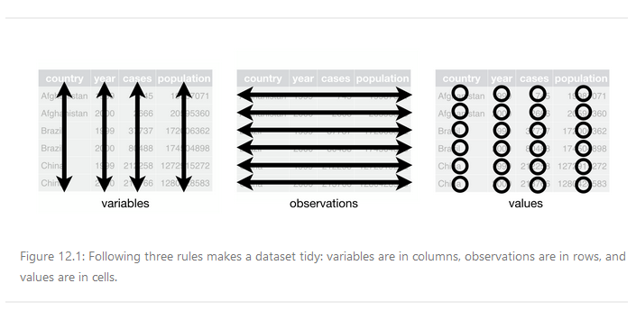

The advantage of tidy data is that each column becomes a vector. R has many functions that work well with vectors. It also follows some of the rules for normalized tables that is required for relational databases. This allows you to join and split tables in a similar way to SQL.

#### Pivot

Untidy data may have two common problems, each with a pivot function that solves it:

1. One variable spread across multiple columns. In the `table4a` example the variable `cases` is spread over two columns, one column called `1999`, and one column called `2000`. These column names are actually values of the data. We can use `pivot_longer()` to combine columns, doubling the number of rows. The `pivot_longer()` function needs the following arguments:
   1. Table name
   2. A vector of columns to combine. Here we must use backticks as the names do not start with a letter.
   3. The name of the new variable to move the old column names to
   4. The name of the new variable to move the column values to

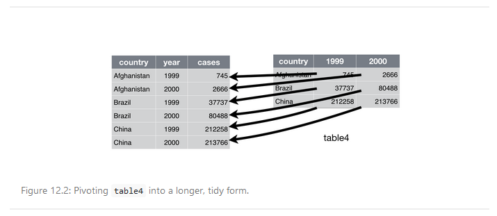

```r
table4a
```

```
#> # A tibble: 3 x 3
#>   country     `1999` `2000`
#> * <chr>        <int>  <int>
#> 1 Afghanistan    745   2666
#> 2 Brazil       37737  80488
#> 3 China       212258 213766
```

```r
pivot_longer(table4a, c(`1999`, `2000`), names_to = "year", values_to = "cases")
```

```
#> # A tibble: 6 x 3
#>   country     year   cases
#>   <chr>       <chr>  <int>
#> 1 Afghanistan 1999     745
#> 2 Afghanistan 2000    2666
#> 3 Brazil      1999   37737
#> 4 Brazil      2000   80488
#> 5 China       1999  212258
#> 6 China       2000  213766
```

2. One observation spread across multiple rows. In the `table2` example the values of `cases` and values `population` are values in the table. `pivot_wider()` moves `cases` and `population` values to their own variable columns. In the picture the column names `key` and `values` should actually be `type` and `count` in order to match the table stored in dplyr. The `pivot_wider()` function needs the following arguments:
   1. Table name
   2. Column to take variable names from
   3. Column to take values from

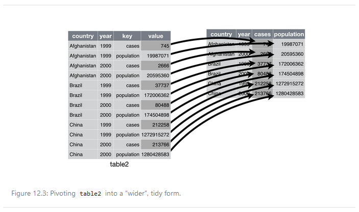

```r
table2
```

```
#> # A tibble: 12 x 4
#>    country      year type            count
#>    <chr>       <int> <chr>           <int>
#>  1 Afghanistan  1999 cases             745
#>  2 Afghanistan  1999 population   19987071
#>  3 Afghanistan  2000 cases            2666
#>  4 Afghanistan  2000 population   20595360
#>  5 Brazil       1999 cases           37737
#>  6 Brazil       1999 population  172006362
#>  7 Brazil       2000 cases           80488
#>  8 Brazil       2000 population  174504898
#>  9 China        1999 cases          212258
#> 10 China        1999 population 1272915272
#> 11 China        2000 cases          213766
#> 12 China        2000 population 1280428583
```

```r
pivot_wider(table2, names_from = type, values_from = count)
```

```
#> # A tibble: 6 x 4
#>   country      year  cases population
#>   <chr>       <int>  <int>      <int>
#> 1 Afghanistan  1999    745   19987071
#> 2 Afghanistan  2000   2666   20595360
#> 3 Brazil       1999  37737  172006362
#> 4 Brazil       2000  80488  174504898
#> 5 China        1999 212258 1272915272
#> 6 China        2000 213766 1280428583
```

#### Separate and Unite

**separate()**

If two variables are in the same column you can use the `separate()` function to split them into multiple columns. In `table3` there is a variable called rate which has info on both case number and population number.

```r
table3
```

```
#> # A tibble: 6 x 3
#>   country      year rate
#> * <chr>       <int> <chr>
#> 1 Afghanistan  1999 745/19987071
#> 2 Afghanistan  2000 2666/20595360
#> 3 Brazil       1999 37737/172006362
#> 4 Brazil       2000 80488/174504898
#> 5 China        1999 212258/1272915272
#> 6 China        2000 213766/1280428583
```

```r
separate(table3, rate, into = c("cases", "population"), sep = "/")
```

```
#> # A tibble: 6 x 4
#>   country      year cases  population
#>   <chr>       <int> <chr>  <chr>
#> 1 Afghanistan  1999 745    19987071
#> 2 Afghanistan  2000 2666   20595360
#> 3 Brazil       1999 37737  172006362
#> 4 Brazil       2000 80488  174504898
#> 5 China        1999 212258 1272915272
#> 6 China        2000 213766 1280428583
```

**unite()**

If you want to combine variables from two column into one you can use the `unite()` function. Less used than separate.

```r
table5
```

```
#> # A tibble: 6 x 4
#>   country     century year  rate
#> * <chr>       <chr>   <chr> <chr>
#> 1 Afghanistan 19      99    745/19987071
#> 2 Afghanistan 20      00    2666/20595360
#> 3 Brazil      19      99    37737/172006362
#> 4 Brazil      20      00    80488/174504898
#> 5 China       19      99    212258/1272915272
#> 6 China       20      00    213766/1280428583
```

```r
unite(table5, new_column_year, century, year, sep = "")
```

```
#> # A tibble: 6 x 3
#>   country     new_column_year rate
#>   <chr>       <chr>           <chr>
#> 1 Afghanistan 1999            745/19987071
#> 2 Afghanistan 2000            2666/20595360
#> 3 Brazil      1999            37737/172006362
#> 4 Brazil      2000            80488/174504898
#> 5 China       1999            212258/1272915272
#> 6 China       2000            213766/1280428583
```

#### Complete

Your data may have NA values. Your data may also have observations that are missing. You can have R check for the absence of observations using the `complete()` function. It uses two existing columns, combines the data in all possible ways (cross joins), looks for any observations in your data that are missing from the cross join, and creates new records with NA values.

E.g. if you recorded an observation every month for 5 years. Using `complete()` with arguments year and month, the function would make sure there 60 observations (5 year X 12 month). If a certain YYYY MM is not found, `complete()` creates that observation and uses NA for any other variables values.

### dplyr Package

- Check out the dplyr Cheat Sheet
  $$dplyr = d\ ata + ply + r$$
- D stands for data. Ply means to work with. R…because its fun to talk like a pirate.
- The dplyr package contains tools for subsetting, summarizing, rearranging, and joining data sets
- Some function names from the dplyr package are the same as built-in functions within the system library. If you want to use these built-in functions after importing the dplyr package you need to specify the built-in package and function with the syntax `package_name::function_name()`.
- Most functions have the DF as the first argument
- Functions do NOT modify the original data frame so you’d have to assign the function output to a variable name to save it.

#### Filter

| Function | Use |
| --- | --- |
| `filter()` | Returns new DF with only those rows/records whose value for a specified column/variable meets the specified condition(s). I.e. filter rows. |
| `between()` | Helper function for `filter()`. Returns TRUE or FALSE. Returns TRUE if specified value is within specified range. Returns FALSE otherwise. Both values that specify the range are inclusive. |

**filter() Rows Simple**

```r
filter(flights, month == 1)
```

```
#> # A tibble: 27,004 x 19
#>     year month   day dep_time sched_dep_time dep_delay arr_time sched_arr_time
#>    <int> <int> <int>    <int>          <int>     <dbl>    <int>          <int>
#>  1  2013     1     1      517            515         2      830            819
#>  2  2013     1     1      533            529         4      850            830
#>  3  2013     1     1      542            540         2      923            850
#>  4  2013     1     1      544            545        -1     1004           1022
#>  5  2013     1     1      554            600        -6      812            837
#>  6  2013     1     1      554            558        -4      740            728
#>  7  2013     1     1      555            600        -5      913            854
#>  8  2013     1     1      557            600        -3      709            723
#>  9  2013     1     1      557            600        -3      838            846
#> 10  2013     1     1      558            600        -2      753            745
#> # ... with 26,994 more rows, and 11 more variables: arr_delay <dbl>,
#> #   carrier <chr>, flight <int>, tailnum <chr>, origin <chr>, dest <chr>,
#> #   air_time <dbl>, distance <dbl>, hour <dbl>, minute <dbl>, time_hour <dttm>
```

**filter() Rows between()**

```r
filter(flights, between(month, 1, 3))
```

```
#> # A tibble: 80,789 x 19
#>     year month   day dep_time sched_dep_time dep_delay arr_time sched_arr_time
#>    <int> <int> <int>    <int>          <int>     <dbl>    <int>          <int>
#>  1  2013     1     1      517            515         2      830            819
#>  2  2013     1     1      533            529         4      850            830
#>  3  2013     1     1      542            540         2      923            850
#>  4  2013     1     1      544            545        -1     1004           1022
#>  5  2013     1     1      554            600        -6      812            837
#>  6  2013     1     1      554            558        -4      740            728
#>  7  2013     1     1      555            600        -5      913            854
#>  8  2013     1     1      557            600        -3      709            723
#>  9  2013     1     1      557            600        -3      838            846
#> 10  2013     1     1      558            600        -2      753            745
#> # ... with 80,779 more rows, and 11 more variables: arr_delay <dbl>,
#> #   carrier <chr>, flight <int>, tailnum <chr>, origin <chr>, dest <chr>,
#> #   air_time <dbl>, distance <dbl>, hour <dbl>, minute <dbl>, time_hour <dttm>
```

**filter() Rows Complex with |, !, and %in%**

```r
# Each additional argument separated by the comma makes the filter more restrictive
filter(flights, month == 1 | month ==2, !(day %in% c(1,2,3) ))
```

```
#> # A tibble: 46,834 x 19
#>     year month   day dep_time sched_dep_time dep_delay arr_time sched_arr_time
#>    <int> <int> <int>    <int>          <int>     <dbl>    <int>          <int>
#>  1  2013     1     4       25           2359        26      505            442
#>  2  2013     1     4      106           2245       141      201           2356
#>  3  2013     1     4      456            500        -4      631            650
#>  4  2013     1     4      520            525        -5      813            820
#>  5  2013     1     4      531            530         1      841            829
#>  6  2013     1     4      546            540         6      851            850
#>  7  2013     1     4      551            600        -9      833            850
#>  8  2013     1     4      551            600        -9      730            759
#>  9  2013     1     4      553            600        -7      846            851
#> 10  2013     1     4      553            600        -7      824            837
#> # ... with 46,824 more rows, and 11 more variables: arr_delay <dbl>,
#> #   carrier <chr>, flight <int>, tailnum <chr>, origin <chr>, dest <chr>,
#> #   air_time <dbl>, distance <dbl>, hour <dbl>, minute <dbl>, time_hour <dttm>
```

**filter() Out Rows with NA**

```r
filter(flights, (is.na(dep_time) == FALSE) )
```

```
#> # A tibble: 328,521 x 19
#>     year month   day dep_time sched_dep_time dep_delay arr_time sched_arr_time
#>    <int> <int> <int>    <int>          <int>     <dbl>    <int>          <int>
#>  1  2013     1     1      517            515         2      830            819
#>  2  2013     1     1      533            529         4      850            830
#>  3  2013     1     1      542            540         2      923            850
#>  4  2013     1     1      544            545        -1     1004           1022
#>  5  2013     1     1      554            600        -6      812            837
#>  6  2013     1     1      554            558        -4      740            728
#>  7  2013     1     1      555            600        -5      913            854
#>  8  2013     1     1      557            600        -3      709            723
#>  9  2013     1     1      557            600        -3      838            846
#> 10  2013     1     1      558            600        -2      753            745
#> # ... with 328,511 more rows, and 11 more variables: arr_delay <dbl>,
#> #   carrier <chr>, flight <int>, tailnum <chr>, origin <chr>, dest <chr>,
#> #   air_time <dbl>, distance <dbl>, hour <dbl>, minute <dbl>, time_hour <dttm>
```

#### Arrange

[output not shown]

**arrange() Rows**

```r
arrange(flights, year, month, day)
```

```
#> # A tibble: 336,776 x 19
#>     year month   day dep_time sched_dep_time dep_delay arr_time sched_arr_time
#>    <int> <int> <int>    <int>          <int>     <dbl>    <int>          <int>
#>  1  2013     1     1      517            515         2      830            819
#>  2  2013     1     1      533            529         4      850            830
#>  3  2013     1     1      542            540         2      923            850
#>  4  2013     1     1      544            545        -1     1004           1022
#>  5  2013     1     1      554            600        -6      812            837
#>  6  2013     1     1      554            558        -4      740            728
#>  7  2013     1     1      555            600        -5      913            854
#>  8  2013     1     1      557            600        -3      709            723
#>  9  2013     1     1      557            600        -3      838            846
#> 10  2013     1     1      558            600        -2      753            745
#> # ... with 336,766 more rows, and 11 more variables: arr_delay <dbl>,
#> #   carrier <chr>, flight <int>, tailnum <chr>, origin <chr>, dest <chr>,
#> #   air_time <dbl>, distance <dbl>, hour <dbl>, minute <dbl>, time_hour <dttm>
```

**arrange() Rows with desc()**

```r
arrange(flights, year, month, desc(day))
```

```
#> # A tibble: 336,776 x 19
#>     year month   day dep_time sched_dep_time dep_delay arr_time sched_arr_time
#>    <int> <int> <int>    <int>          <int>     <dbl>    <int>          <int>
#>  1  2013     1    31        1           2100       181      124           2225
#>  2  2013     1    31        4           2359         5      455            444
#>  3  2013     1    31        7           2359         8      453            437
#>  4  2013     1    31       12           2250        82      132              7
#>  5  2013     1    31       26           2154       152      328             50
#>  6  2013     1    31       34           2159       155      135           2315
#>  7  2013     1    31       37           2249       108      132           2357
#>  8  2013     1    31       54           2250       124      152           2359
#>  9  2013     1    31      453            500        -7      651            648
#> 10  2013     1    31      522            525        -3      820            820
#> # ... with 336,766 more rows, and 11 more variables: arr_delay <dbl>,
#> #   carrier <chr>, flight <int>, tailnum <chr>, origin <chr>, dest <chr>,
#> #   air_time <dbl>, distance <dbl>, hour <dbl>, minute <dbl>, time_hour <dttm>
```

**arrange() Rows with NA First**

```r
arrange(flights, desc(is.na(dep_time)) )
```

```
#> # A tibble: 336,776 x 19
#>     year month   day dep_time sched_dep_time dep_delay arr_time sched_arr_time
#>    <int> <int> <int>    <int>          <int>     <dbl>    <int>          <int>
#>  1  2013     1     1       NA           1630        NA       NA           1815
#>  2  2013     1     1       NA           1935        NA       NA           2240
#>  3  2013     1     1       NA           1500        NA       NA           1825
#>  4  2013     1     1       NA            600        NA       NA            901
#>  5  2013     1     2       NA           1540        NA       NA           1747
#>  6  2013     1     2       NA           1620        NA       NA           1746
#>  7  2013     1     2       NA           1355        NA       NA           1459
#>  8  2013     1     2       NA           1420        NA       NA           1644
#>  9  2013     1     2       NA           1321        NA       NA           1536
#> 10  2013     1     2       NA           1545        NA       NA           1910
#> # ... with 336,766 more rows, and 11 more variables: arr_delay <dbl>,
#> #   carrier <chr>, flight <int>, tailnum <chr>, origin <chr>, dest <chr>,
#> #   air_time <dbl>, distance <dbl>, hour <dbl>, minute <dbl>, time_hour <dttm>
```

#### Select

[output not shown]

**select() Columns**

```r
select(flights, year, month, day)
```

```
#> # A tibble: 336,776 x 3
#>     year month   day
#>    <int> <int> <int>
#>  1  2013     1     1
#>  2  2013     1     1
#>  3  2013     1     1
#>  4  2013     1     1
#>  5  2013     1     1
#>  6  2013     1     1
#>  7  2013     1     1
#>  8  2013     1     1
#>  9  2013     1     1
#> 10  2013     1     1
#> # ... with 336,766 more rows
```

**select() Columns Except Those Indicated**

```r
select(flights, -c(year))
```

```
#> # A tibble: 336,776 x 18
#>    month   day dep_time sched_dep_time dep_delay arr_time sched_arr_time
#>    <int> <int>    <int>          <int>     <dbl>    <int>          <int>
#>  1     1     1      517            515         2      830            819
#>  2     1     1      533            529         4      850            830
#>  3     1     1      542            540         2      923            850
#>  4     1     1      544            545        -1     1004           1022
#>  5     1     1      554            600        -6      812            837
#>  6     1     1      554            558        -4      740            728
#>  7     1     1      555            600        -5      913            854
#>  8     1     1      557            600        -3      709            723
#>  9     1     1      557            600        -3      838            846
#> 10     1     1      558            600        -2      753            745
#> # ... with 336,766 more rows, and 11 more variables: arr_delay <dbl>,
#> #   carrier <chr>, flight <int>, tailnum <chr>, origin <chr>, dest <chr>,
#> #   air_time <dbl>, distance <dbl>, hour <dbl>, minute <dbl>, time_hour <dttm>
```

**select() Columns with Helper Function**

```r
select(flights, starts_with("d"))
```

```
#> # A tibble: 336,776 x 5
#>      day dep_time dep_delay dest  distance
#>    <int>    <int>     <dbl> <chr>    <dbl>
#>  1     1      517         2 IAH       1400
#>  2     1      533         4 IAH       1416
#>  3     1      542         2 MIA       1089
#>  4     1      544        -1 BQN       1576
#>  5     1      554        -6 ATL        762
#>  6     1      554        -4 ORD        719
#>  7     1      555        -5 FLL       1065
#>  8     1      557        -3 IAD        229
#>  9     1      557        -3 MCO        944
#> 10     1      558        -2 ORD        733
#> # ... with 336,766 more rows
```

**select() Columns with Everything()**

```r
select(flights, air_time, everything())
```

```
#> # A tibble: 336,776 x 19
#>    air_time  year month   day dep_time sched_dep_time dep_delay arr_time
#>       <dbl> <int> <int> <int>    <int>          <int>     <dbl>    <int>
#>  1      227  2013     1     1      517            515         2      830
#>  2      227  2013     1     1      533            529         4      850
#>  3      160  2013     1     1      542            540         2      923
#>  4      183  2013     1     1      544            545        -1     1004
#>  5      116  2013     1     1      554            600        -6      812
#>  6      150  2013     1     1      554            558        -4      740
#>  7      158  2013     1     1      555            600        -5      913
#>  8       53  2013     1     1      557            600        -3      709
#>  9      140  2013     1     1      557            600        -3      838
#> 10      138  2013     1     1      558            600        -2      753
#> # ... with 336,766 more rows, and 11 more variables: sched_arr_time <int>,
#> #   arr_delay <dbl>, carrier <chr>, flight <int>, tailnum <chr>, origin <chr>,
#> #   dest <chr>, distance <dbl>, hour <dbl>, minute <dbl>, time_hour <dttm>
```

#### Mutate and Rename

[output not shown]

```r
rename(flights, earth_revolution = year)
```

```
#> # A tibble: 336,776 x 19
#>    earth_revolution month   day dep_time sched_dep_time dep_delay arr_time
#>               <int> <int> <int>    <int>          <int>     <dbl>    <int>
#>  1             2013     1     1      517            515         2      830
#>  2             2013     1     1      533            529         4      850
#>  3             2013     1     1      542            540         2      923
#>  4             2013     1     1      544            545        -1     1004
#>  5             2013     1     1      554            600        -6      812
#>  6             2013     1     1      554            558        -4      740
#>  7             2013     1     1      555            600        -5      913
#>  8             2013     1     1      557            600        -3      709
#>  9             2013     1     1      557            600        -3      838
#> 10             2013     1     1      558            600        -2      753
#> # ... with 336,766 more rows, and 12 more variables: sched_arr_time <int>,
#> #   arr_delay <dbl>, carrier <chr>, flight <int>, tailnum <chr>, origin <chr>,
#> #   dest <chr>, air_time <dbl>, distance <dbl>, hour <dbl>, minute <dbl>,
#> #   time_hour <dttm>
```

**mutate() Column**

```r
flights_sm <- select(flights, distance, air_time) # Select columns of interest
mutate(flights_sm, av_speed = distance/air_time * 60)
```

```
#> # A tibble: 336,776 x 3
#>    distance air_time av_speed
#>       <dbl>    <dbl>    <dbl>
#>  1     1400      227     370.
#>  2     1416      227     374.
#>  3     1089      160     408.
#>  4     1576      183     517.
#>  5      762      116     394.
#>  6      719      150     288.
#>  7     1065      158     404.
#>  8      229       53     259.
#>  9      944      140     405.
#> 10      733      138     319.
#> # ... with 336,766 more rows
```

**mutate() with if_else()**

```r
select(flights, arr_delay) %>% # Select columns of interest
  mutate(arr_delay_change = if_else(arr_delay <= 0, "Decrease", "Increase"))
```

```
#> # A tibble: 336,776 x 2
#>    arr_delay arr_delay_change
#>        <dbl> <chr>
#>  1        11 Increase
#>  2        20 Increase
#>  3        33 Increase
#>  4       -18 Decrease
#>  5       -25 Decrease
#>  6        12 Increase
#>  7        19 Increase
#>  8       -14 Decrease
#>  9        -8 Decrease
#> 10         8 Increase
#> # ... with 336,766 more rows
```

**mutate() with if_else()**

Assigning a 1 or a 0 seems like a helpful binary output

```r
select(flights, arr_delay) %>% # Select columns of interest
  mutate(arr_delay_increase = if_else(arr_delay <= 0, 0, 1))
```

```
#> # A tibble: 336,776 x 2
#>    arr_delay arr_delay_increase
#>        <dbl>              <dbl>
#>  1        11                  1
#>  2        20                  1
#>  3        33                  1
#>  4       -18                  0
#>  5       -25                  0
#>  6        12                  1
#>  7        19                  1
#>  8       -14                  0
#>  9        -8                  0
#> 10         8                  1
#> # ... with 336,766 more rows
```

**mutate() with case_when()**

```r
select(flights, sched_dep_time) %>% # Select columns of interest
  mutate(part_of_day = case_when(
    sched_dep_time <= 800 ~ "Morning Flight",
    between(sched_dep_time, 801, 1700) ~ "Daytime Flight",
    between(sched_dep_time, 1701, 2400) ~ "Evening Flight"
    )
  )
```

```
#> # A tibble: 336,776 x 2
#>    sched_dep_time part_of_day
#>             <int> <chr>
#>  1            515 Morning Flight
#>  2            529 Morning Flight
#>  3            540 Morning Flight
#>  4            545 Morning Flight
#>  5            600 Morning Flight
#>  6            558 Morning Flight
#>  7            600 Morning Flight
#>  8            600 Morning Flight
#>  9            600 Morning Flight
#> 10            600 Morning Flight
#> # ... with 336,766 more rows
```

**mutate() with case_when() and Math Expression**

The example does not provide any useful information

```r
select(flights, sched_dep_time, air_time) %>% # Select columns of interest
  mutate(hour_you_will_sleep_on_flight = case_when(
    sched_dep_time <= 800 ~ (air_time - 60),
    between(sched_dep_time, 801, 1700) ~  (air_time - 180),
    between(sched_dep_time, 1701, 2400) ~ (air_time - 120)
    )
  )
```

```
#> # A tibble: 336,776 x 3
#>    sched_dep_time air_time hour_you_will_sleep_on_flight
#>             <int>    <dbl>                         <dbl>
#>  1            515      227                           167
#>  2            529      227                           167
#>  3            540      160                           100
#>  4            545      183                           123
#>  5            600      116                            56
#>  6            558      150                            90
#>  7            600      158                            98
#>  8            600       53                            -7
#>  9            600      140                            80
#> 10            600      138                            78
#> # ... with 336,766 more rows
```

#### Summarize

[output not shown]

**summarize() with No Groups and na.rm =**

```r
summarize(flights, mean_delay = mean(dep_delay, na.rm = TRUE))
```

```
#> # A tibble: 1 x 1
#>   mean_delay
#>        <dbl>
#> 1       12.6
```

**group_by() One Column**

```r
(by_dest <- group_by(flights, dest))
```

```
#> # A tibble: 336,776 x 19
#> # Groups:   dest [105]
#>     year month   day dep_time sched_dep_time dep_delay arr_time sched_arr_time
#>    <int> <int> <int>    <int>          <int>     <dbl>    <int>          <int>
#>  1  2013     1     1      517            515         2      830            819
#>  2  2013     1     1      533            529         4      850            830
#>  3  2013     1     1      542            540         2      923            850
#>  4  2013     1     1      544            545        -1     1004           1022
#>  5  2013     1     1      554            600        -6      812            837
#>  6  2013     1     1      554            558        -4      740            728
#>  7  2013     1     1      555            600        -5      913            854
#>  8  2013     1     1      557            600        -3      709            723
#>  9  2013     1     1      557            600        -3      838            846
#> 10  2013     1     1      558            600        -2      753            745
#> # ... with 336,766 more rows, and 11 more variables: arr_delay <dbl>,
#> #   carrier <chr>, flight <int>, tailnum <chr>, origin <chr>, dest <chr>,
#> #   air_time <dbl>, distance <dbl>, hour <dbl>, minute <dbl>, time_hour <dttm>
```

**group_by() Multiple Columns**

```r
(by_day <- group_by(flights, year, month, day))
```

```
#> # A tibble: 336,776 x 19
#> # Groups:   year, month, day [365]
#>     year month   day dep_time sched_dep_time dep_delay arr_time sched_arr_time
#>    <int> <int> <int>    <int>          <int>     <dbl>    <int>          <int>
#>  1  2013     1     1      517            515         2      830            819
#>  2  2013     1     1      533            529         4      850            830
#>  3  2013     1     1      542            540         2      923            850
#>  4  2013     1     1      544            545        -1     1004           1022
#>  5  2013     1     1      554            600        -6      812            837
#>  6  2013     1     1      554            558        -4      740            728
#>  7  2013     1     1      555            600        -5      913            854
#>  8  2013     1     1      557            600        -3      709            723
#>  9  2013     1     1      557            600        -3      838            846
#> 10  2013     1     1      558            600        -2      753            745
#> # ... with 336,766 more rows, and 11 more variables: arr_delay <dbl>,
#> #   carrier <chr>, flight <int>, tailnum <chr>, origin <chr>, dest <chr>,
#> #   air_time <dbl>, distance <dbl>, hour <dbl>, minute <dbl>, time_hour <dttm>
```

**summarize() with group_by() and Statistical Function**

Group flights by destination and find average delay:

```r
by_dest <- group_by(flights, dest)
summarize(by_dest, delay = mean(dep_delay, na.rm = TRUE))
```

```
#> # A tibble: 105 x 2
#>    dest  delay
#>    <chr> <dbl>
#>  1 ABQ   13.7
#>  2 ACK    6.46
#>  3 ALB   23.6
#>  4 ANC   12.9
#>  5 ATL   12.5
#>  6 AUS   13.0
#>  7 AVL    8.19
#>  8 BDL   17.7
#>  9 BGR   19.5
#> 10 BHM   29.7
#> # ... with 95 more rows
```

**summarize() with group_by() and n()**

Count number of rows in each group. Here we also pipe it into arrange so that we can sort it by destinations with the most flights.

```r
by_dest <- group_by(flights, dest)
summarize(by_dest, total_flights_to_destination = n()) %>%
  arrange(desc(total_flights_to_destination))
```

```
#> # A tibble: 105 x 2
#>    dest  total_flights_to_destination
#>    <chr>                        <int>
#>  1 ORD                          17283
#>  2 ATL                          17215
#>  3 LAX                          16174
#>  4 BOS                          15508
#>  5 MCO                          14082
#>  6 CLT                          14064
#>  7 SFO                          13331
#>  8 FLL                          12055
#>  9 MIA                          11728
#> 10 DCA                           9705
#> # ... with 95 more rows
```

**summarize() with group_by() and sum(!is.na())**

Same as `summarize()` with `n()`, but makes sure to exclude NA values

```r
group_by(flights, dest) %>%
  summarize(total_flights_to_destination = sum(!is.na(dest))) %>%
  arrange(desc(total_flights_to_destination))
```

```
#> # A tibble: 105 x 2
#>    dest  total_flights_to_destination
#>    <chr>                        <int>
#>  1 ORD                          17283
#>  2 ATL                          17215
#>  3 LAX                          16174
#>  4 BOS                          15508
#>  5 MCO                          14082
#>  6 CLT                          14064
#>  7 SFO                          13331
#>  8 FLL                          12055
#>  9 MIA                          11728
#> 10 DCA                           9705
#> # ... with 95 more rows
```

**count()**

Same as using group_by(), summarize() and n() together. Here we include new column name (optional) and sort (also optional).

```r
count(flights, dest, sort = TRUE, name = "total_flights_to_destination")
```

```
#> # A tibble: 105 x 2
#>    dest  total_flights_to_destination
#>    <chr>                        <int>
#>  1 ORD                          17283
#>  2 ATL                          17215
#>  3 LAX                          16174
#>  4 BOS                          15508
#>  5 MCO                          14082
#>  6 CLT                          14064
#>  7 SFO                          13331
#>  8 FLL                          12055
#>  9 MIA                          11728
#> 10 DCA                           9705
#> # ... with 95 more rows
```

**`across()`**

```r
df_na_count <- flights %>%
  summarise(across(everything(), function(x) sum(is.na(x))))
df_na_count
```

```
#> # A tibble: 1 x 19
#>    year month   day dep_time sched_dep_time dep_delay arr_time sched_arr_time
#>   <int> <int> <int>    <int>          <int>     <int>    <int>          <int>
#> 1     0     0     0     8255              0      8255     8713              0
#> # ... with 11 more variables: arr_delay <int>, carrier <int>, flight <int>,
#> #   tailnum <int>, origin <int>, dest <int>, air_time <int>, distance <int>,
#> #   hour <int>, minute <int>, time_hour <int>
```

OR

```r
df_na_count <- flights %>%
  summarise(across(everything(), ~sum(is.na(.x))))
df_na_count
```

```
#> # A tibble: 1 x 19
#>    year month   day dep_time sched_dep_time dep_delay arr_time sched_arr_time
#>   <int> <int> <int>    <int>          <int>     <int>    <int>          <int>
#> 1     0     0     0     8255              0      8255     8713              0
#> # ... with 11 more variables: arr_delay <int>, carrier <int>, flight <int>,
#> #   tailnum <int>, origin <int>, dest <int>, air_time <int>, distance <int>,
#> #   hour <int>, minute <int>, time_hour <int>
```